# examples_0602

Identify the coordinates of the vertices.

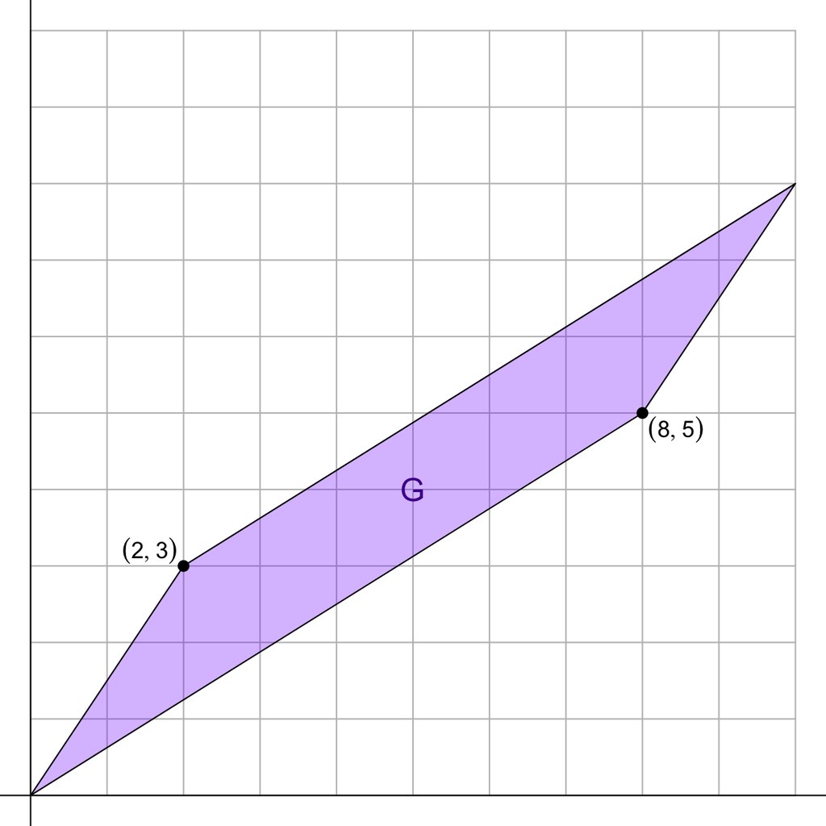

- $x_1 = 8$
- $y_1 = 5$
- $x_2 = 2$
- $y_2 = 3$

Use the formula.

$$G=|8\cdot3-2\cdot5|$$
$$G=14$$

A $2\times 2$ matrix is often interpreted as two 2D points. We could think of each row (or each column) as representing a point in the $(x,y)$ plane.

$$A~=~\begin{bmatrix}x_1 & y_1 \\ x_2
& y_2\end{bmatrix}$$

The [determinant](https://en.wikipedia.org/wiki/Determinant) is defined as follows:

$$\det(A)~=~x_1 y_2 - x_2y_1$$

Let's practice evaluating the determinant.

$$B=\begin{bmatrix}5 & 1 \\ 5 &
6\end{bmatrix}$$

Evaluate $\det(B)$.

$$\det(B) ~=~ 5\cdot6 - 5\cdot1$$
$$\det(B) ~=~ 25$$

Notice, this also is the area of the parallelogram shown below:

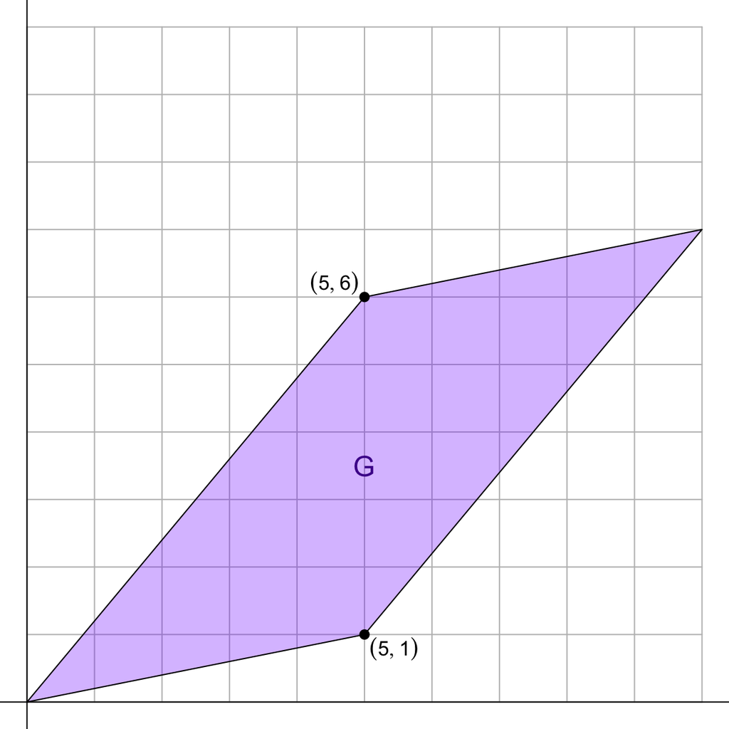

$$G=25$$

A $2\times 2$ matrix is often interpreted as two 2D points. We could think of each row (or each column) as representing a point in the $(x,y)$ plane.

$$A~=~\begin{bmatrix}x_1 & y_1 \\ x_2
& y_2\end{bmatrix}$$

The [determinant](https://en.wikipedia.org/wiki/Determinant) is defined as follows:

$$\det(A)~=~x_1 y_2 - x_2y_1$$

Let's practice evaluating the determinant.

$$B=\begin{bmatrix}4 & 2 \\ 6 &
8\end{bmatrix}$$

Evaluate $\det(B)$.

$$\det(B) ~=~ 4\cdot8 - 6\cdot2$$
$$\det(B) ~=~ 20$$

Notice, this also is the area of the parallelogram shown below:

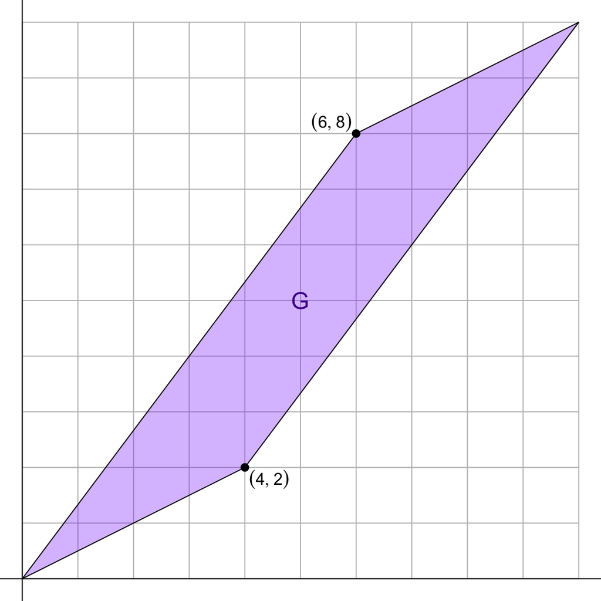

$$G=20$$

A $2\times 2$ matrix is often interpreted as two 2D points. We could think of each row (or each column) as representing a point in the $(x,y)$ plane.

$$A~=~\begin{bmatrix}x_1 & y_1 \\ x_2
& y_2\end{bmatrix}$$

The [determinant](https://en.wikipedia.org/wiki/Determinant) is defined as follows:

$$\det(A)~=~x_1 y_2 - x_2y_1$$

Let's practice evaluating the determinant.

$$B=\begin{bmatrix}6 & 2 \\ 2 &
4\end{bmatrix}$$

Evaluate $\det(B)$.

$$\det(B) ~=~ 6\cdot4 - 2\cdot2$$
$$\det(B) ~=~ 20$$

Notice, this also is the area of the parallelogram shown below:

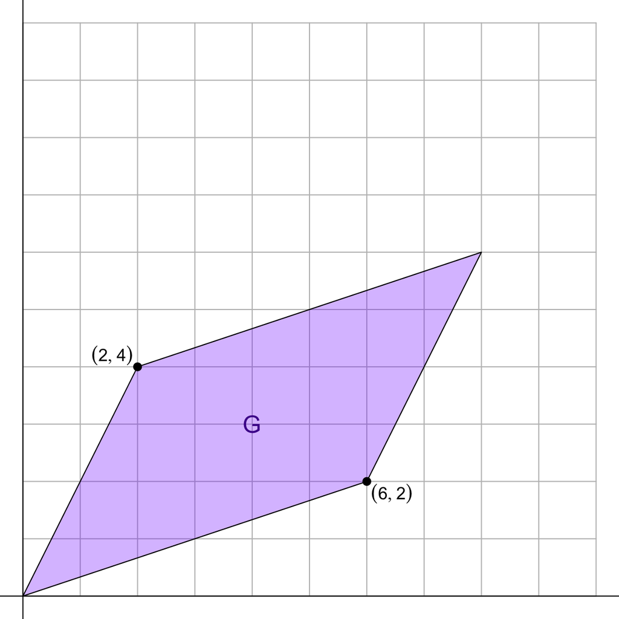

$$G=20$$

A $2\times 2$ matrix is often interpreted as two 2D points. We could think of each row (or each column) as representing a point in the $(x,y)$ plane.

$$A~=~\begin{bmatrix}x_1 & y_1 \\ x_2
& y_2\end{bmatrix}$$

The [determinant](https://en.wikipedia.org/wiki/Determinant) is defined as follows:

$$\det(A)~=~x_1 y_2 - x_2y_1$$

Let's practice evaluating the determinant.

$$B=\begin{bmatrix}9 & 8 \\ 1 &
2\end{bmatrix}$$

Evaluate $\det(B)$.

$$\det(B) ~=~ 9\cdot2 - 1\cdot8$$
$$\det(B) ~=~ 10$$

Notice, this also is the area of the parallelogram shown below:

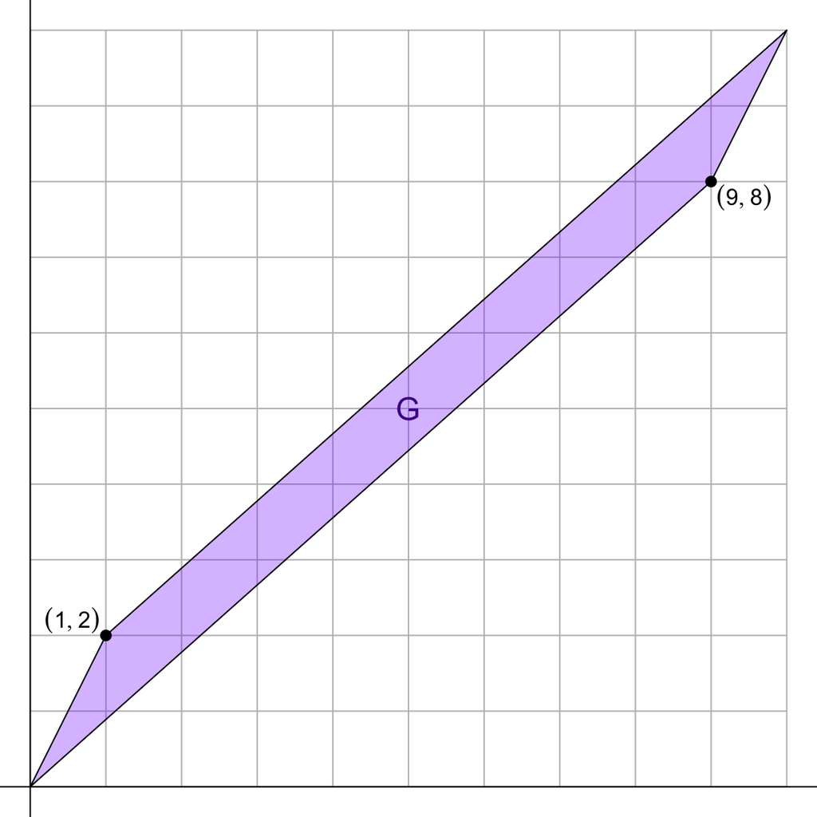

$$G=10$$

A $2\times 2$ matrix is often interpreted as two 2D points. We could think of each row (or each column) as representing a point in the $(x,y)$ plane.

$$A~=~\begin{bmatrix}x_1 & y_1 \\ x_2
& y_2\end{bmatrix}$$

The [determinant](https://en.wikipedia.org/wiki/Determinant) is defined as follows:

$$\det(A)~=~x_1 y_2 - x_2y_1$$

Let's practice evaluating the determinant.

$$B=\begin{bmatrix}2 & 1 \\ 7 &
9\end{bmatrix}$$

Evaluate $\det(B)$.

$$\det(B) ~=~ 2\cdot9 - 7\cdot1$$
$$\det(B) ~=~ 11$$

Notice, this also is the area of the parallelogram shown below:

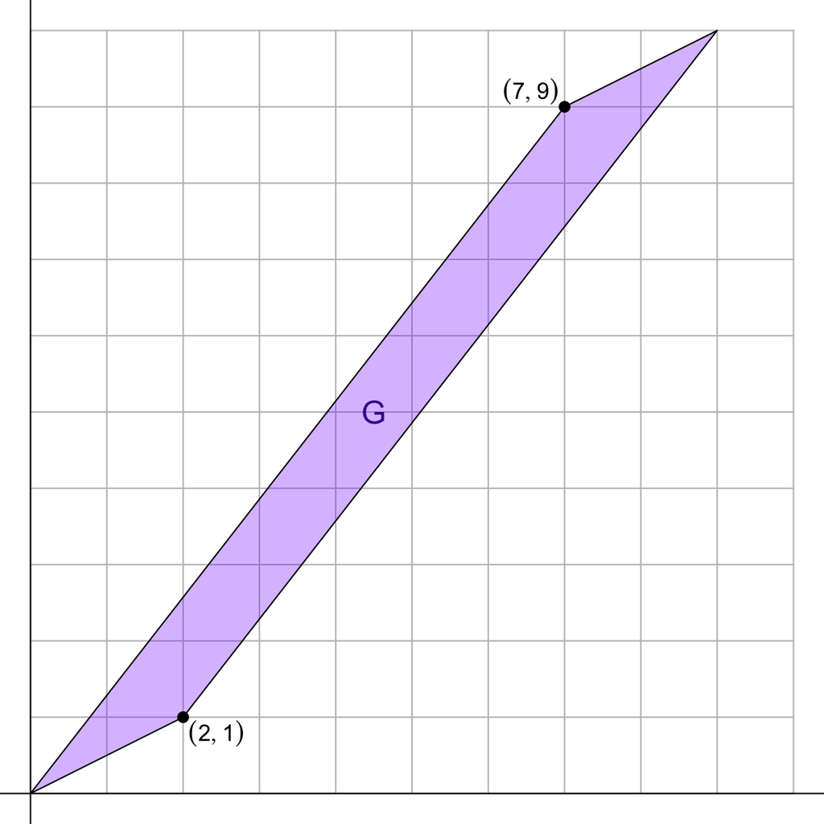

$$G=11$$

A $2\times 2$ matrix is often interpreted as two 2D points. We could think of each row (or each column) as representing a point in the $(x,y)$ plane.

$$A~=~\begin{bmatrix}x_1 & y_1 \\ x_2
& y_2\end{bmatrix}$$

The [determinant](https://en.wikipedia.org/wiki/Determinant) is defined as follows:

$$\det(A)~=~x_1 y_2 - x_2y_1$$

Let's practice evaluating the determinant.

$$B=\begin{bmatrix}8 & 1 \\ 1 &
5\end{bmatrix}$$

Evaluate $\det(B)$.

$$\det(B) ~=~ 8\cdot5 - 1\cdot1$$
$$\det(B) ~=~ 39$$

Notice, this also is the area of the parallelogram shown below:

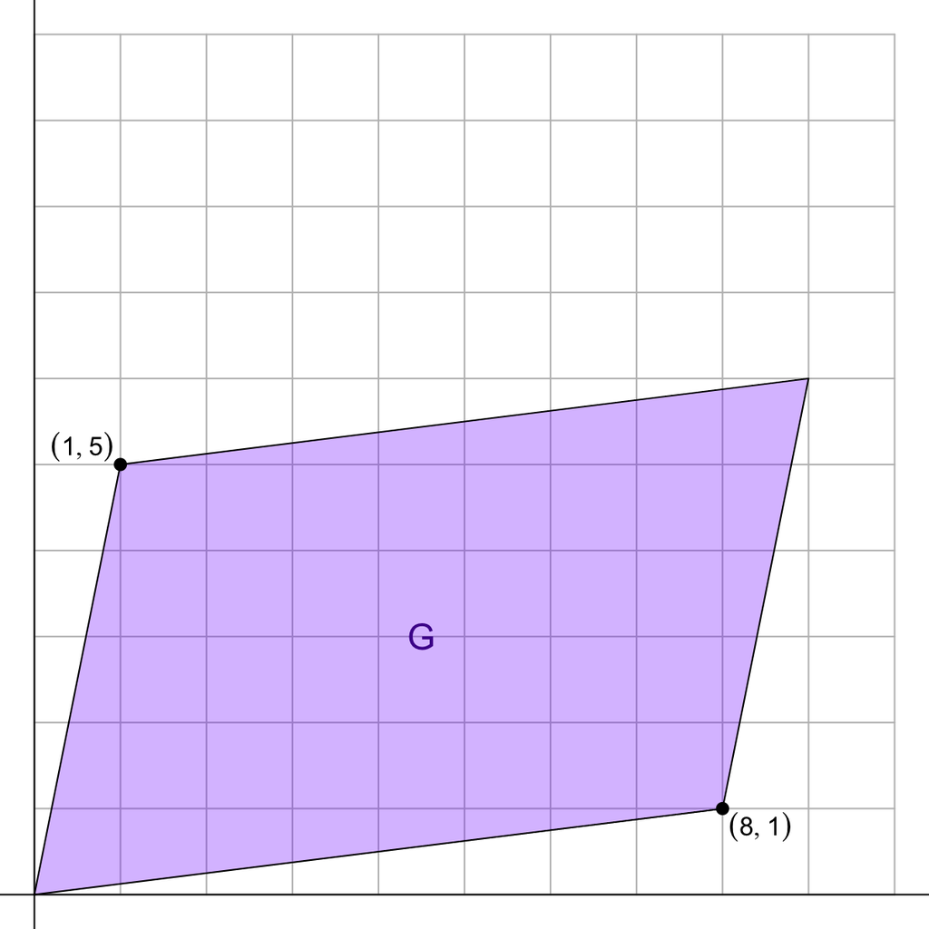

$$G=39$$

A $2\times 2$ matrix is often interpreted as two 2D points. We could think of each row (or each column) as representing a point in the $(x,y)$ plane.

$$A~=~\begin{bmatrix}x_1 & y_1 \\ x_2
& y_2\end{bmatrix}$$

The [determinant](https://en.wikipedia.org/wiki/Determinant) is defined as follows:

$$\det(A)~=~x_1 y_2 - x_2y_1$$

Let's practice evaluating the determinant.

$$B=\begin{bmatrix}4 & 2 \\ 2 &
5\end{bmatrix}$$

Evaluate $\det(B)$.

$$\det(B) ~=~ 4\cdot5 - 2\cdot2$$
$$\det(B) ~=~ 16$$

Notice, this also is the area of the parallelogram shown below:

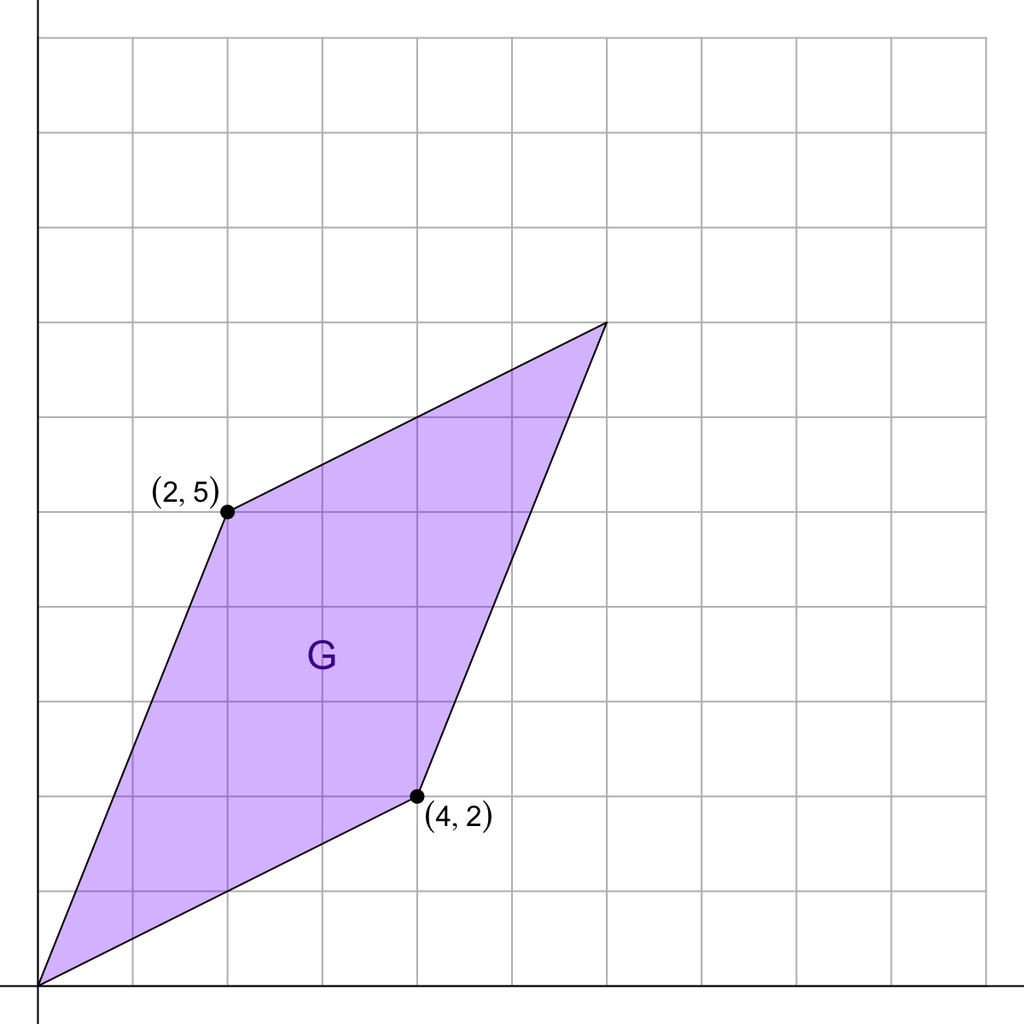

$$G=16$$

A $2\times 2$ matrix is often interpreted as two 2D points. We could think of each row (or each column) as representing a point in the $(x,y)$ plane.

$$A~=~\begin{bmatrix}x_1 & y_1 \\ x_2
& y_2\end{bmatrix}$$

The [determinant](https://en.wikipedia.org/wiki/Determinant) is defined as follows:

$$\det(A)~=~x_1 y_2 - x_2y_1$$

Let's practice evaluating the determinant.

$$B=\begin{bmatrix}2 & 1 \\ 8 &
9\end{bmatrix}$$

Evaluate $\det(B)$.

$$\det(B) ~=~ 2\cdot9 - 8\cdot1$$
$$\det(B) ~=~ 10$$

Notice, this also is the area of the parallelogram shown below:

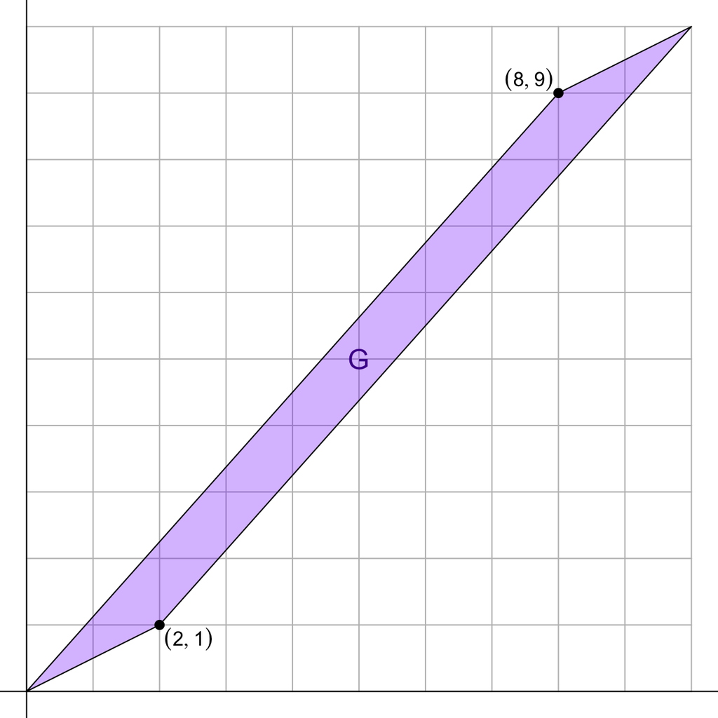

$$G=10$$

A $2\times 2$ matrix is often interpreted as two 2D points. We could think of each row (or each column) as representing a point in the $(x,y)$ plane.

$$A~=~\begin{bmatrix}x_1 & y_1 \\ x_2
& y_2\end{bmatrix}$$

The [determinant](https://en.wikipedia.org/wiki/Determinant) is defined as follows:

$$\det(A)~=~x_1 y_2 - x_2y_1$$

Let's practice evaluating the determinant.

$$B=\begin{bmatrix}4 & 1 \\ 6 &
6\end{bmatrix}$$

Evaluate $\det(B)$.

$$\det(B) ~=~ 4\cdot6 - 6\cdot1$$
$$\det(B) ~=~ 18$$

Notice, this also is the area of the parallelogram shown below:

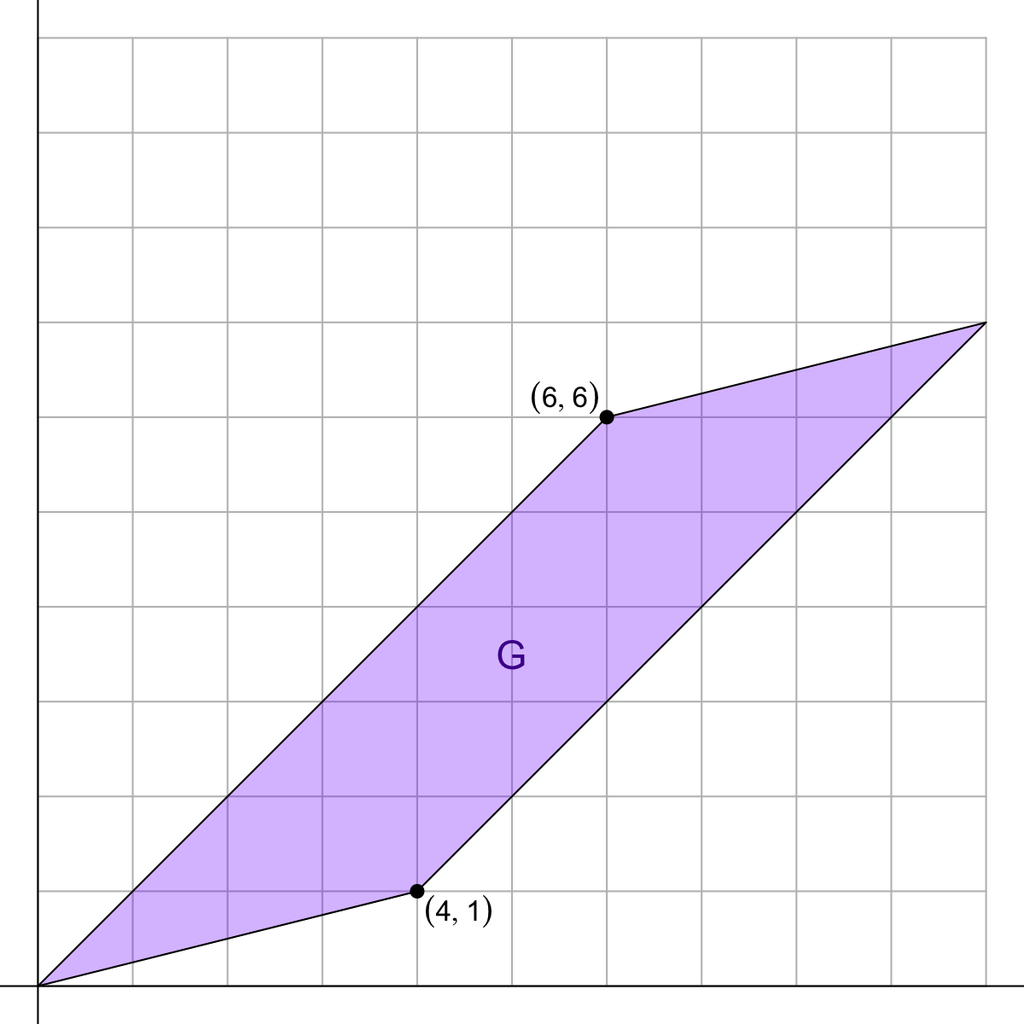

$$G=18$$

A $2\times 2$ matrix is often interpreted as two 2D points. We could think of each row (or each column) as representing a point in the $(x,y)$ plane.

$$A~=~\begin{bmatrix}x_1 & y_1 \\ x_2
& y_2\end{bmatrix}$$

The [determinant](https://en.wikipedia.org/wiki/Determinant) is defined as follows:

$$\det(A)~=~x_1 y_2 - x_2y_1$$

Let's practice evaluating the determinant.

$$B=\begin{bmatrix}3 & 1 \\ 4 &
7\end{bmatrix}$$

Evaluate $\det(B)$.

$$\det(B) ~=~ 3\cdot7 - 4\cdot1$$
$$\det(B) ~=~ 17$$

Notice, this also is the area of the parallelogram shown below:

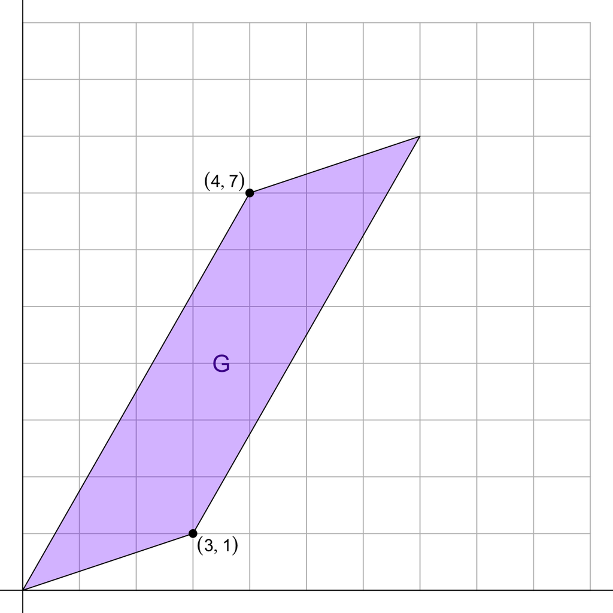

$$G=17$$

A $2\times 2$ matrix is often interpreted as two 2D points. We could think of each row (or each column) as representing a point in the $(x,y)$ plane.

$$A~=~\begin{bmatrix}x_1 & y_1 \\ x_2
& y_2\end{bmatrix}$$

The [determinant](https://en.wikipedia.org/wiki/Determinant) is defined as follows:

$$\det(A)~=~x_1 y_2 - x_2y_1$$

Let's practice evaluating the determinant.

$$B=\begin{bmatrix}2 & 1 \\ 5 &
8\end{bmatrix}$$

Evaluate $\det(B)$.

$$\det(B) ~=~ 2\cdot8 - 5\cdot1$$
$$\det(B) ~=~ 11$$

Notice, this also is the area of the parallelogram shown below:

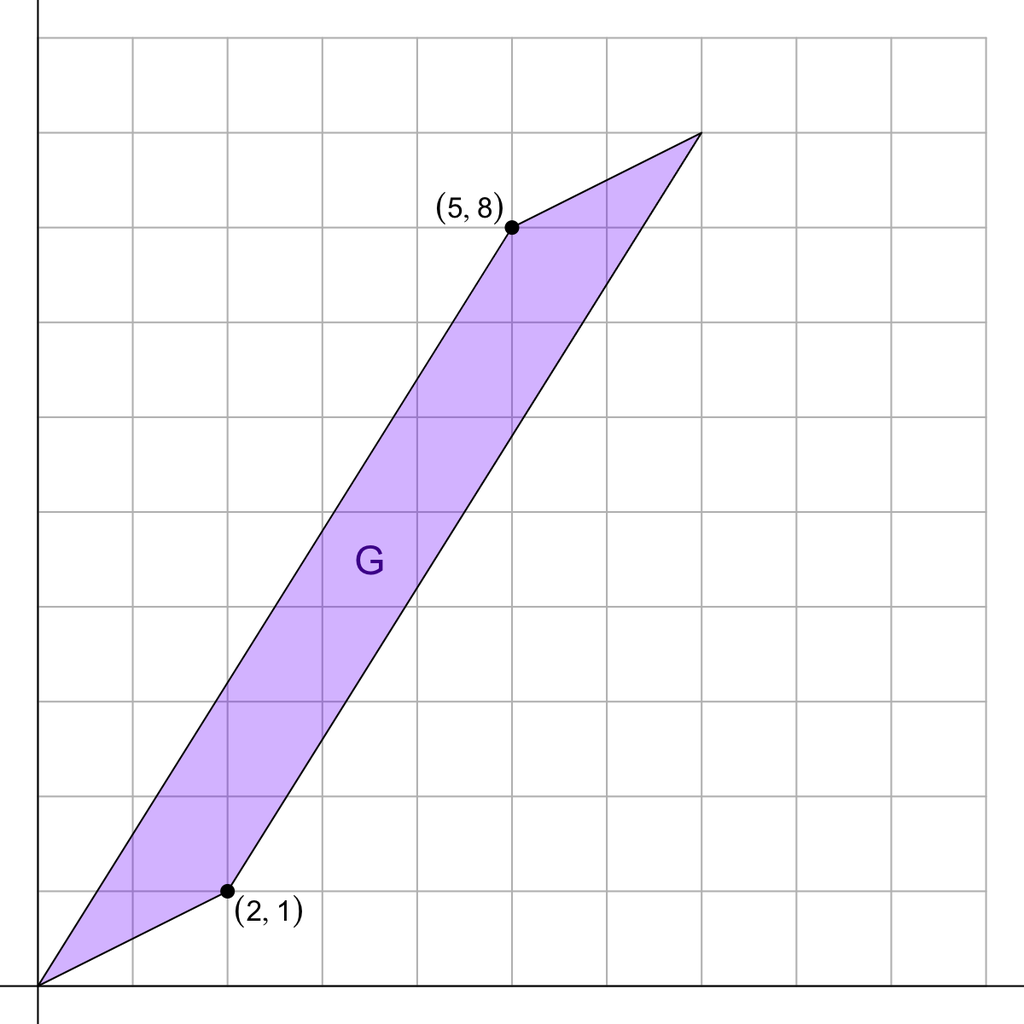

$$G=11$$

A $2\times 2$ matrix is often interpreted as two 2D points. We could think of each row (or each column) as representing a point in the $(x,y)$ plane.

$$A~=~\begin{bmatrix}x_1 & y_1 \\ x_2
& y_2\end{bmatrix}$$

The [determinant](https://en.wikipedia.org/wiki/Determinant) is defined as follows:

$$\det(A)~=~x_1 y_2 - x_2y_1$$

Let's practice evaluating the determinant.

$$B=\begin{bmatrix}6 & 7 \\ 1 &
3\end{bmatrix}$$

Evaluate $\det(B)$.

$$\det(B) ~=~ 6\cdot3 - 1\cdot7$$
$$\det(B) ~=~ 11$$

Notice, this also is the area of the parallelogram shown below:

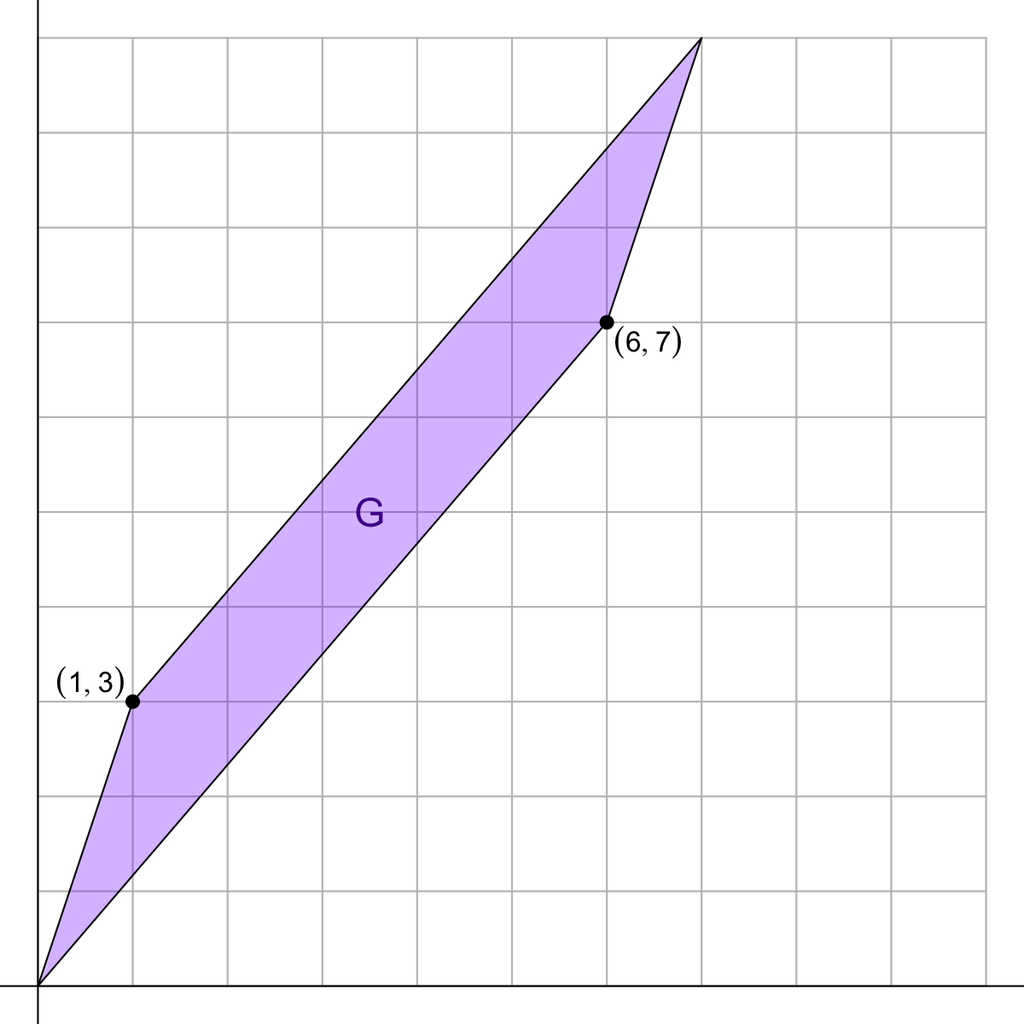

$$G=11$$

A $2\times 2$ matrix is often interpreted as two 2D points. We could think of each row (or each column) as representing a point in the $(x,y)$ plane.

$$A~=~\begin{bmatrix}x_1 & y_1 \\ x_2
& y_2\end{bmatrix}$$

The [determinant](https://en.wikipedia.org/wiki/Determinant) is defined as follows:

$$\det(A)~=~x_1 y_2 - x_2y_1$$

Let's practice evaluating the determinant.

$$B=\begin{bmatrix}6 & 5 \\ 1 &
4\end{bmatrix}$$

Evaluate $\det(B)$.

$$\det(B) ~=~ 6\cdot4 - 1\cdot5$$
$$\det(B) ~=~ 19$$

Notice, this also is the area of the parallelogram shown below:

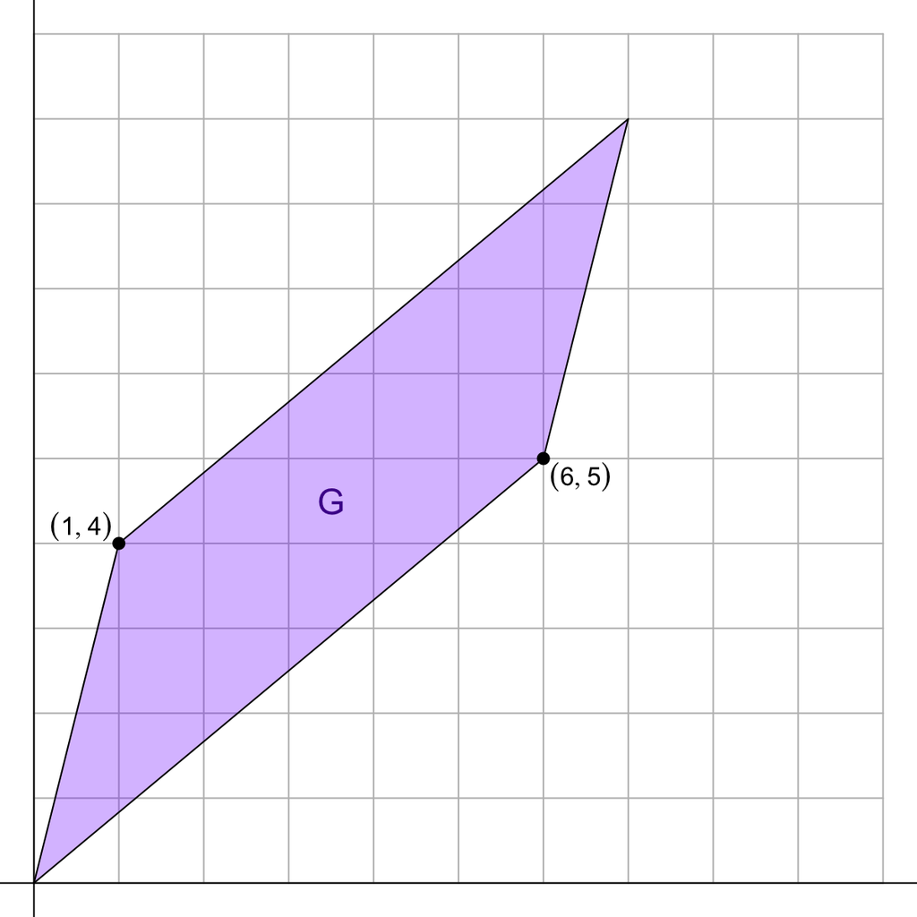

$$G=19$$

A $2\times 2$ matrix is often interpreted as two 2D points. We could think of each row (or each column) as representing a point in the $(x,y)$ plane.

$$A~=~\begin{bmatrix}x_1 & y_1 \\ x_2
& y_2\end{bmatrix}$$

The [determinant](https://en.wikipedia.org/wiki/Determinant) is defined as follows:

$$\det(A)~=~x_1 y_2 - x_2y_1$$

Let's practice evaluating the determinant.

$$B=\begin{bmatrix}6 & 3 \\ 2 &
5\end{bmatrix}$$

Evaluate $\det(B)$.

$$\det(B) ~=~ 6\cdot5 - 2\cdot3$$
$$\det(B) ~=~ 24$$

Notice, this also is the area of the parallelogram shown below:

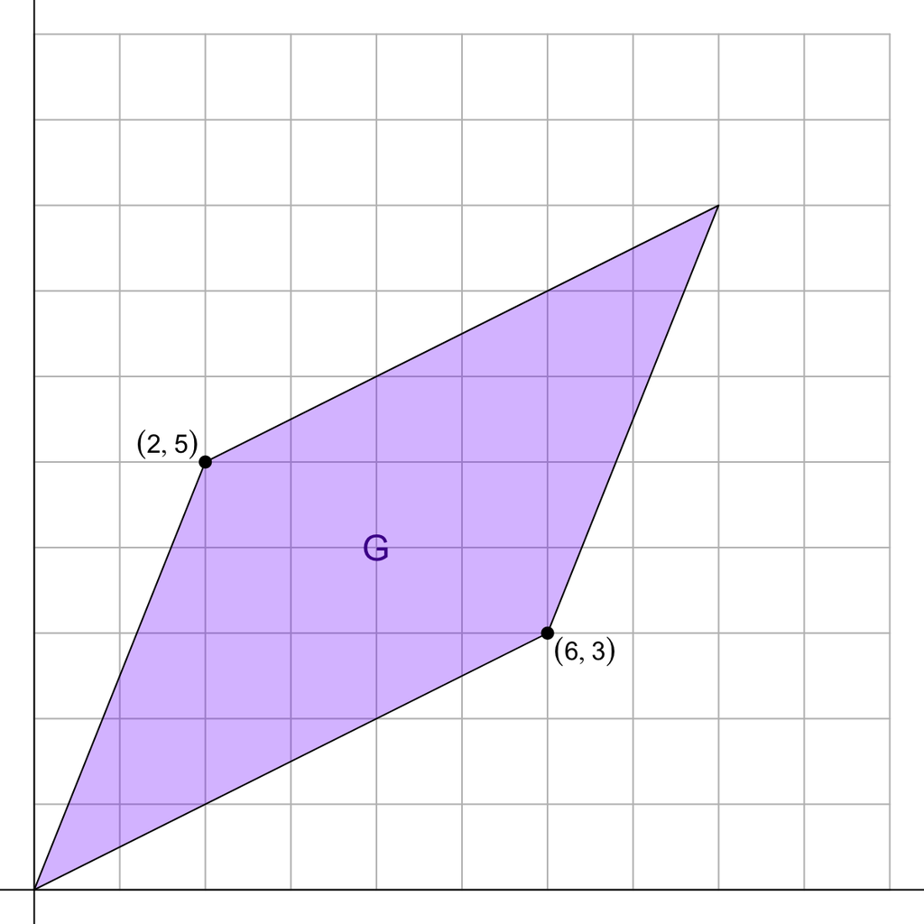

$$G=24$$

A $2\times 2$ matrix is often interpreted as two 2D points. We could think of each row (or each column) as representing a point in the $(x,y)$ plane.

$$A~=~\begin{bmatrix}x_1 & y_1 \\ x_2
& y_2\end{bmatrix}$$

The [determinant](https://en.wikipedia.org/wiki/Determinant) is defined as follows:

$$\det(A)~=~x_1 y_2 - x_2y_1$$

Let's practice evaluating the determinant.

$$B=\begin{bmatrix}3 & 3 \\ 3 &
7\end{bmatrix}$$

Evaluate $\det(B)$.

$$\det(B) ~=~ 3\cdot7 - 3\cdot3$$
$$\det(B) ~=~ 12$$

Notice, this also is the area of the parallelogram shown below:

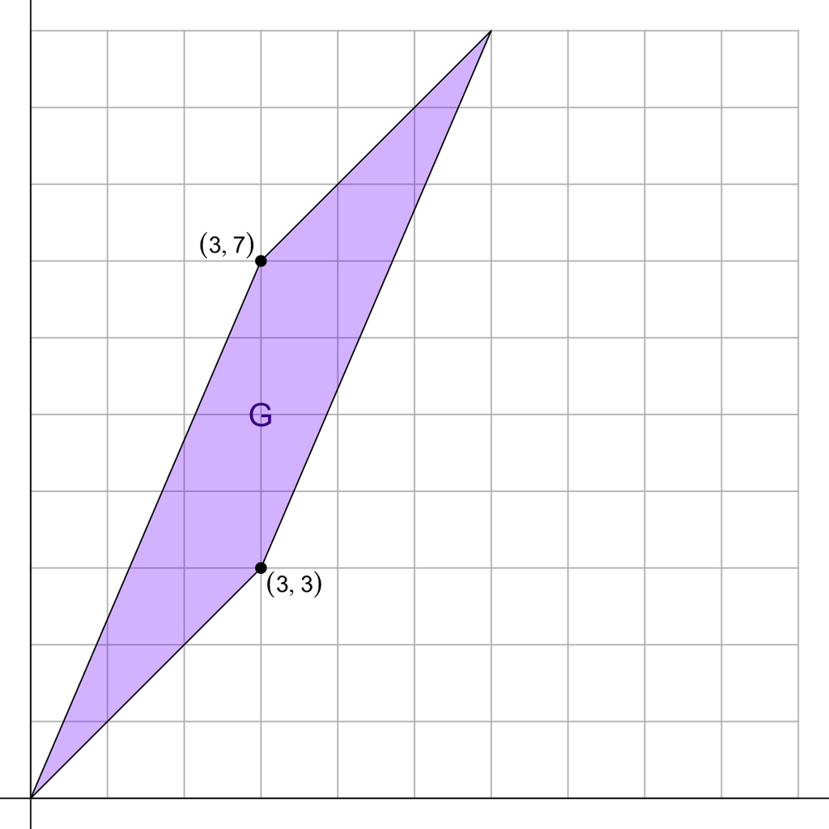

$$G=12$$

A $2\times 2$ matrix is often interpreted as two 2D points. We could think of each row (or each column) as representing a point in the $(x,y)$ plane.

$$A~=~\begin{bmatrix}x_1 & y_1 \\ x_2
& y_2\end{bmatrix}$$

The [determinant](https://en.wikipedia.org/wiki/Determinant) is defined as follows:

$$\det(A)~=~x_1 y_2 - x_2y_1$$

Let's practice evaluating the determinant.

$$B=\begin{bmatrix}3 & 2 \\ 6 &
8\end{bmatrix}$$

Evaluate $\det(B)$.

$$\det(B) ~=~ 3\cdot8 - 6\cdot2$$
$$\det(B) ~=~ 12$$

Notice, this also is the area of the parallelogram shown below:

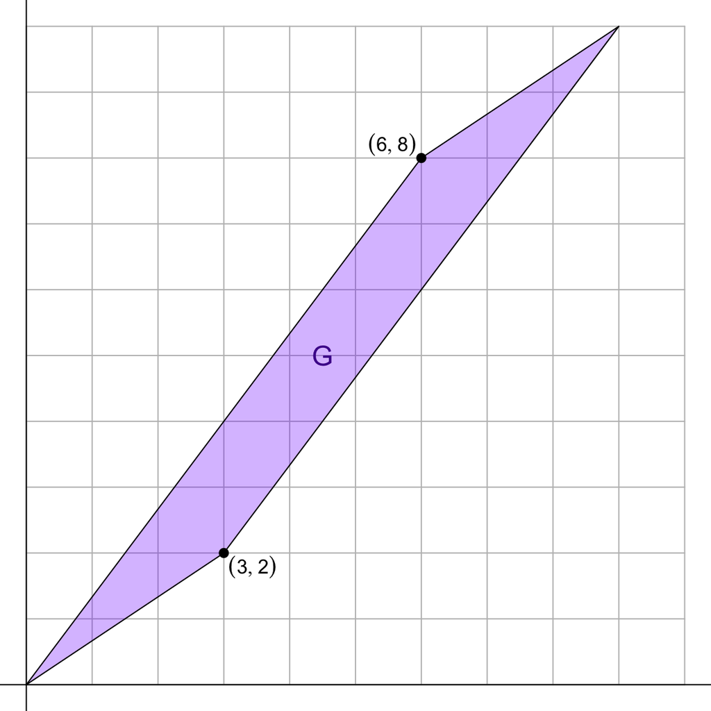

$$G=12$$

A $2\times 2$ matrix is often interpreted as two 2D points. We could think of each row (or each column) as representing a point in the $(x,y)$ plane.

$$A~=~\begin{bmatrix}x_1 & y_1 \\ x_2
& y_2\end{bmatrix}$$

The [determinant](https://en.wikipedia.org/wiki/Determinant) is defined as follows:

$$\det(A)~=~x_1 y_2 - x_2y_1$$

Let's practice evaluating the determinant.

$$B=\begin{bmatrix}3 & 1 \\ 5 &
7\end{bmatrix}$$

Evaluate $\det(B)$.

$$\det(B) ~=~ 3\cdot7 - 5\cdot1$$
$$\det(B) ~=~ 16$$

Notice, this also is the area of the parallelogram shown below:

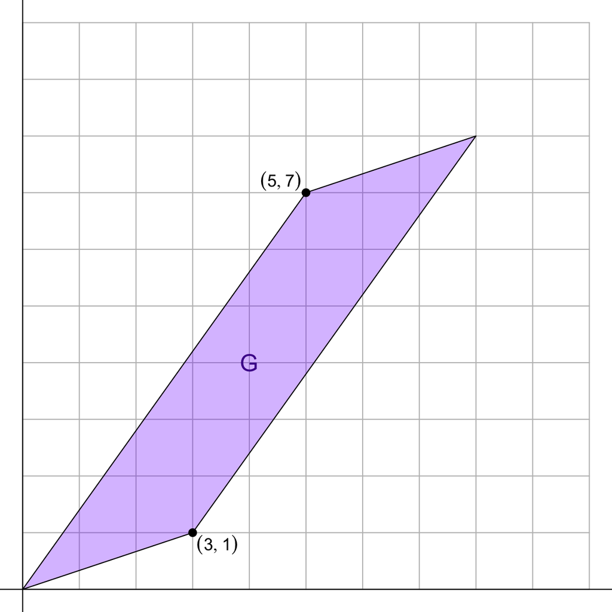

$$G=16$$

A $2\times 2$ matrix is often interpreted as two 2D points. We could think of each row (or each column) as representing a point in the $(x,y)$ plane.

$$A~=~\begin{bmatrix}x_1 & y_1 \\ x_2
& y_2\end{bmatrix}$$

The [determinant](https://en.wikipedia.org/wiki/Determinant) is defined as follows:

$$\det(A)~=~x_1 y_2 - x_2y_1$$

Let's practice evaluating the determinant.

$$B=\begin{bmatrix}3 & 2 \\ 3 &
8\end{bmatrix}$$

Evaluate $\det(B)$.

$$\det(B) ~=~ 3\cdot8 - 3\cdot2$$
$$\det(B) ~=~ 18$$

Notice, this also is the area of the parallelogram shown below:

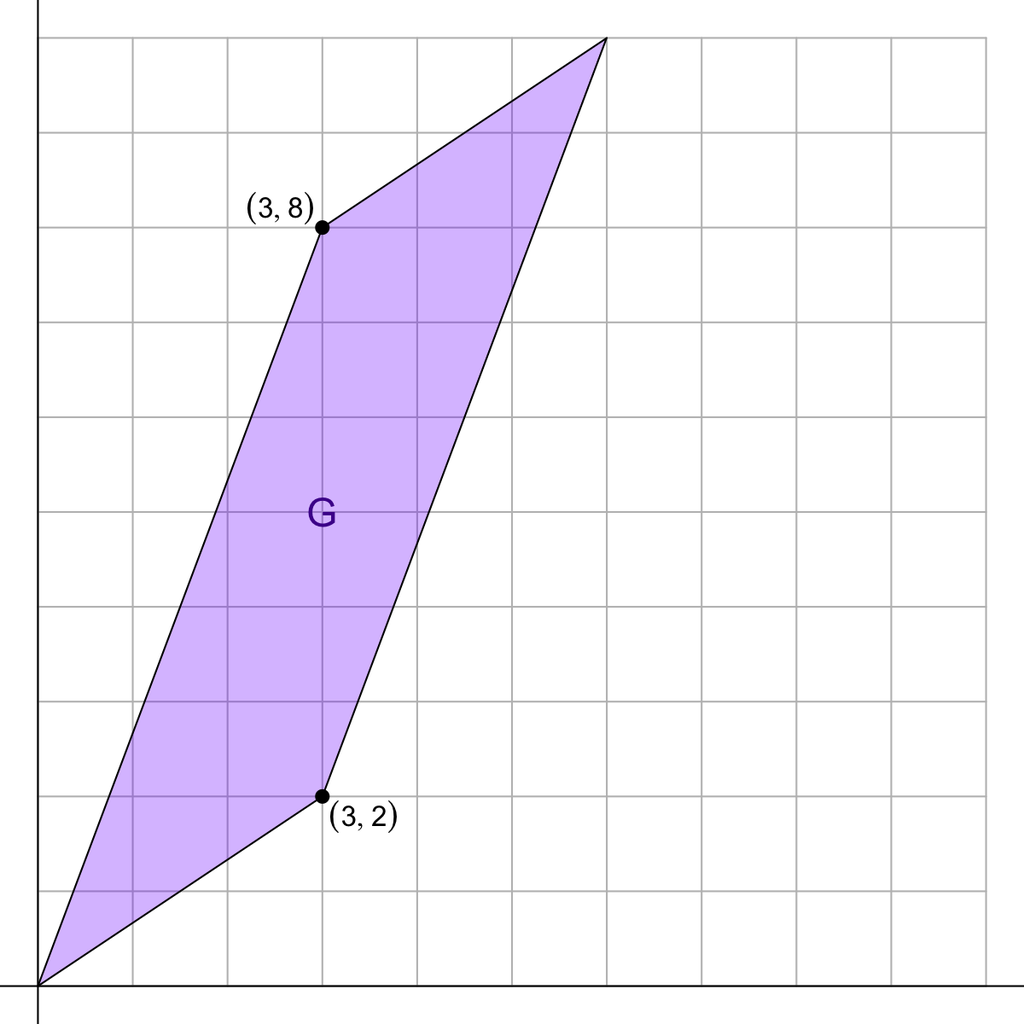

$$G=18$$

A $2\times 2$ matrix is often interpreted as two 2D points. We could think of each row (or each column) as representing a point in the $(x,y)$ plane.

$$A~=~\begin{bmatrix}x_1 & y_1 \\ x_2
& y_2\end{bmatrix}$$

The [determinant](https://en.wikipedia.org/wiki/Determinant) is defined as follows:

$$\det(A)~=~x_1 y_2 - x_2y_1$$

Let's practice evaluating the determinant.

$$B=\begin{bmatrix}3 & 1 \\ 5 &
5\end{bmatrix}$$

Evaluate $\det(B)$.

$$\det(B) ~=~ 3\cdot5 - 5\cdot1$$
$$\det(B) ~=~ 10$$

Notice, this also is the area of the parallelogram shown below:

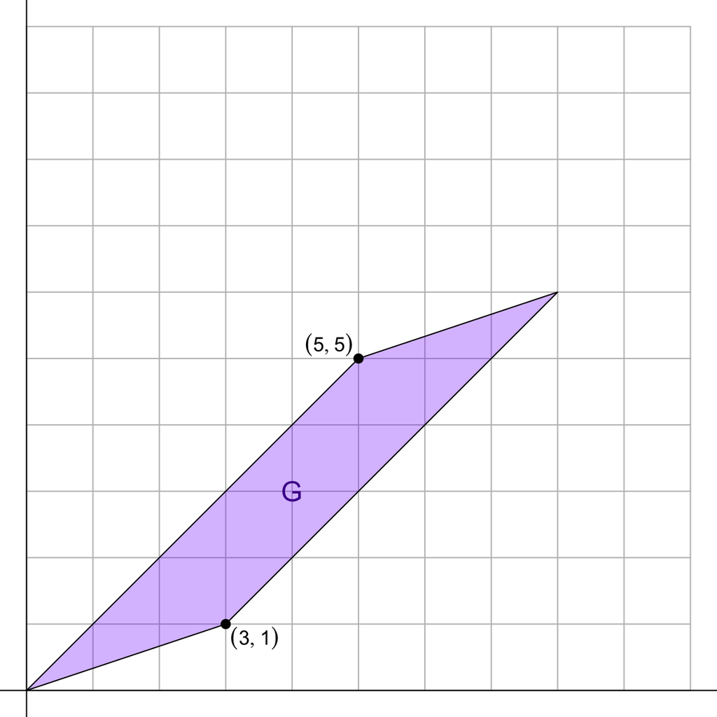

$$G=10$$

A $2\times 2$ matrix is often interpreted as two 2D points. We could think of each row (or each column) as representing a point in the $(x,y)$ plane.

$$A~=~\begin{bmatrix}x_1 & y_1 \\ x_2
& y_2\end{bmatrix}$$

The [determinant](https://en.wikipedia.org/wiki/Determinant) is defined as follows:

$$\det(A)~=~x_1 y_2 - x_2y_1$$

Let's practice evaluating the determinant.

$$B=\begin{bmatrix}6 & 3 \\ 4 &
6\end{bmatrix}$$

Evaluate $\det(B)$.

$$\det(B) ~=~ 6\cdot6 - 4\cdot3$$
$$\det(B) ~=~ 24$$

Notice, this also is the area of the parallelogram shown below:

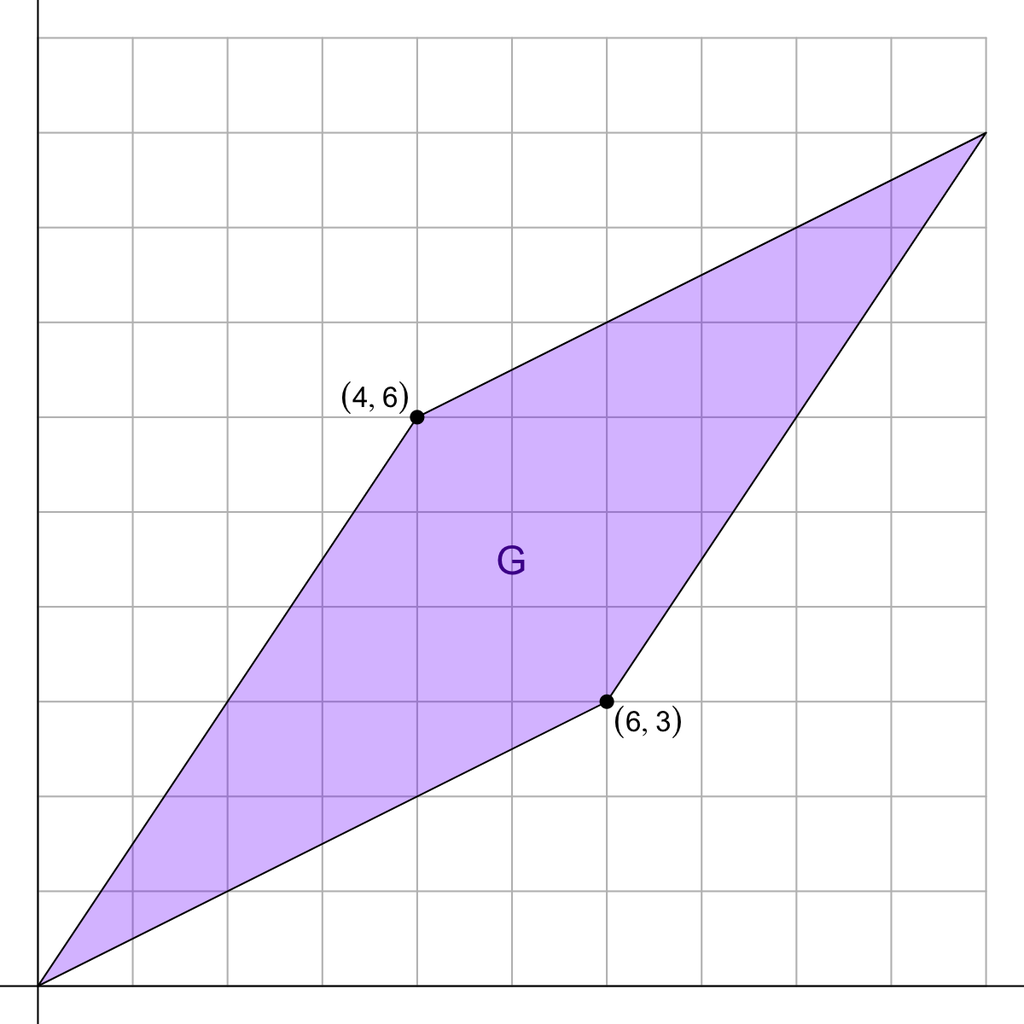

$$G=24$$

A [linear 2-equation-2-variable system](https://en.wikipedia.org/wiki/System_of_linear_equations) of equations can be expressed generally in standard form, using 6 parameters ($a$ through $f$) and 2 variables ($x$ and $y$).

$$\begin{align}ax+by &= c \\ dx+ey
&=f\end{align}$$

Using determinants, we can express [Cramer's rule](https://en.wikipedia.org/wiki/Cramer%27s_rule), which gives us the solutions to the system:

$$x = \frac{\det\left(\begin{bmatrix}c
& b\\ f & e\end{bmatrix}\right)}{\det\left(\begin{bmatrix}a
& b\\ d &
e\end{bmatrix}\right)}~=~\frac{ce-bf}{ae-bd}$$

and

$$y = \frac{\det\left(\begin{bmatrix}a
& c\\ d & f\end{bmatrix}\right)}{\det\left(\begin{bmatrix}a
& b\\ d &
e\end{bmatrix}\right)}~=~\frac{af-cd}{ae-bd}$$

Using Cramer's rule, solve the linear system below:

$$\begin{align}2x+9y&=12\\-8x+3y&=7\end{align}$$

Express your answers in decimal form rounded to the hundredths place.

- $x=$
- $y=$

Use Cramer's rule. Here is the given system:

$$\begin{align}2x+9y&=12\\-8x+3y&=7\end{align}$$

Identify the parameters as defined in the general desciption.

$$a=2$$
$$b=9$$
$$c=12$$
$$d=-8$$
$$e=3$$
$$f=7$$

Put parameters into the formula for $x$.

$$x = \frac{\det\left(\begin{bmatrix}c
& b\\ f & e\end{bmatrix}\right)}{\det\left(\begin{bmatrix}a
& b\\ d &
e\end{bmatrix}\right)}~=~\frac{\det\left(\begin{bmatrix}12 & 9\\ 7
& 3\end{bmatrix}\right)}{\det\left(\begin{bmatrix}2 & 9\\ -8
& 3\end{bmatrix}\right)}$$

Remember how to calculate a [determinant](https://en.wikipedia.org/wiki/Determinant).

$$\begin{align}x~&=~\frac{(12)(3)-(9)(7)}{(2)(3)-(9)(-8)}\\\\
x~&=~ \frac{-27}{78} \\\\
x~&\approx~ -0.35
\end{align}$$

Put parameters into the formula for $y$.

$$y = \frac{\det\left(\begin{bmatrix}a
& c\\ d & f\end{bmatrix}\right)}{\det\left(\begin{bmatrix}a
& b\\ d &
e\end{bmatrix}\right)}~=~\frac{\det\left(\begin{bmatrix}2 & 12\\ -8
& 7\end{bmatrix}\right)}{\det\left(\begin{bmatrix}2 & 9\\ -8
& 3\end{bmatrix}\right)}$$

$$\begin{align}y~&=~\frac{(2)(7)-(12)(-8)}{(2)(3)-(9)(-8)}\\\\
y~&=~ \frac{110}{78} \\\\
y~&\approx~ 1.41
\end{align}$$

A [linear 2-equation-2-variable system](https://en.wikipedia.org/wiki/System_of_linear_equations) of equations can be expressed generally in standard form, using 6 parameters ($a$ through $f$) and 2 variables ($x$ and $y$).

$$\begin{align}ax+by &= c \\ dx+ey
&=f\end{align}$$

Using determinants, we can express [Cramer's rule](https://en.wikipedia.org/wiki/Cramer%27s_rule), which gives us the solutions to the system:

$$x = \frac{\det\left(\begin{bmatrix}c
& b\\ f & e\end{bmatrix}\right)}{\det\left(\begin{bmatrix}a
& b\\ d &
e\end{bmatrix}\right)}~=~\frac{ce-bf}{ae-bd}$$

and

$$y = \frac{\det\left(\begin{bmatrix}a
& c\\ d & f\end{bmatrix}\right)}{\det\left(\begin{bmatrix}a
& b\\ d &
e\end{bmatrix}\right)}~=~\frac{af-cd}{ae-bd}$$

Using Cramer's rule, solve the linear system below:

$$\begin{align}5x-11y&=12\\2x+9y&=8\end{align}$$

Express your answers in decimal form rounded to the hundredths place.

- $x=$
- $y=$

Use Cramer's rule. Here is the given system:

$$\begin{align}5x-11y&=12\\2x+9y&=8\end{align}$$

Identify the parameters as defined in the general desciption.

$$a=5$$
$$b=-11$$
$$c=12$$
$$d=2$$
$$e=9$$
$$f=8$$

Put parameters into the formula for $x$.

$$x = \frac{\det\left(\begin{bmatrix}c
& b\\ f & e\end{bmatrix}\right)}{\det\left(\begin{bmatrix}a
& b\\ d &
e\end{bmatrix}\right)}~=~\frac{\det\left(\begin{bmatrix}12 & -11\\ 8
& 9\end{bmatrix}\right)}{\det\left(\begin{bmatrix}5 & -11\\ 2
& 9\end{bmatrix}\right)}$$

Remember how to calculate a [determinant](https://en.wikipedia.org/wiki/Determinant).

$$\begin{align}x~&=~\frac{(12)(9)-(-11)(8)}{(5)(9)-(-11)(2)}\\\\
x~&=~ \frac{196}{67} \\\\
x~&\approx~ 2.93
\end{align}$$

Put parameters into the formula for $y$.

$$y = \frac{\det\left(\begin{bmatrix}a
& c\\ d & f\end{bmatrix}\right)}{\det\left(\begin{bmatrix}a
& b\\ d &
e\end{bmatrix}\right)}~=~\frac{\det\left(\begin{bmatrix}5 & 12\\ 2
& 8\end{bmatrix}\right)}{\det\left(\begin{bmatrix}5 & -11\\ 2
& 9\end{bmatrix}\right)}$$

$$\begin{align}y~&=~\frac{(5)(8)-(12)(2)}{(5)(9)-(-11)(2)}\\\\
y~&=~ \frac{16}{67} \\\\
y~&\approx~ 0.24
\end{align}$$

A [linear 2-equation-2-variable system](https://en.wikipedia.org/wiki/System_of_linear_equations) of equations can be expressed generally in standard form, using 6 parameters ($a$ through $f$) and 2 variables ($x$ and $y$).

$$\begin{align}ax+by &= c \\ dx+ey
&=f\end{align}$$

Using determinants, we can express [Cramer's rule](https://en.wikipedia.org/wiki/Cramer%27s_rule), which gives us the solutions to the system:

$$x = \frac{\det\left(\begin{bmatrix}c
& b\\ f & e\end{bmatrix}\right)}{\det\left(\begin{bmatrix}a
& b\\ d &
e\end{bmatrix}\right)}~=~\frac{ce-bf}{ae-bd}$$

and

$$y = \frac{\det\left(\begin{bmatrix}a
& c\\ d & f\end{bmatrix}\right)}{\det\left(\begin{bmatrix}a
& b\\ d &
e\end{bmatrix}\right)}~=~\frac{af-cd}{ae-bd}$$

Using Cramer's rule, solve the linear system below:

$$\begin{align}7x-3y&=2\\-11x+10y&=4\end{align}$$

Express your answers in decimal form rounded to the hundredths place.

- $x=$
- $y=$

Use Cramer's rule. Here is the given system:

$$\begin{align}7x-3y&=2\\-11x+10y&=4\end{align}$$

Identify the parameters as defined in the general desciption.

$$a=7$$
$$b=-3$$
$$c=2$$
$$d=-11$$
$$e=10$$
$$f=4$$

Put parameters into the formula for $x$.

$$x = \frac{\det\left(\begin{bmatrix}c
& b\\ f & e\end{bmatrix}\right)}{\det\left(\begin{bmatrix}a
& b\\ d &
e\end{bmatrix}\right)}~=~\frac{\det\left(\begin{bmatrix}2 & -3\\ 4
& 10\end{bmatrix}\right)}{\det\left(\begin{bmatrix}7 & -3\\ -11
& 10\end{bmatrix}\right)}$$

Remember how to calculate a [determinant](https://en.wikipedia.org/wiki/Determinant).

$$\begin{align}x~&=~\frac{(2)(10)-(-3)(4)}{(7)(10)-(-3)(-11)}\\\\
x~&=~ \frac{32}{37} \\\\
x~&\approx~ 0.86
\end{align}$$

Put parameters into the formula for $y$.

$$y = \frac{\det\left(\begin{bmatrix}a
& c\\ d & f\end{bmatrix}\right)}{\det\left(\begin{bmatrix}a
& b\\ d &
e\end{bmatrix}\right)}~=~\frac{\det\left(\begin{bmatrix}7 & 2\\ -11
& 4\end{bmatrix}\right)}{\det\left(\begin{bmatrix}7 & -3\\ -11
& 10\end{bmatrix}\right)}$$

$$\begin{align}y~&=~\frac{(7)(4)-(2)(-11)}{(7)(10)-(-3)(-11)}\\\\
y~&=~ \frac{50}{37} \\\\
y~&\approx~ 1.35
\end{align}$$

A [linear 2-equation-2-variable system](https://en.wikipedia.org/wiki/System_of_linear_equations) of equations can be expressed generally in standard form, using 6 parameters ($a$ through $f$) and 2 variables ($x$ and $y$).

$$\begin{align}ax+by &= c \\ dx+ey
&=f\end{align}$$

Using determinants, we can express [Cramer's rule](https://en.wikipedia.org/wiki/Cramer%27s_rule), which gives us the solutions to the system:

$$x = \frac{\det\left(\begin{bmatrix}c
& b\\ f & e\end{bmatrix}\right)}{\det\left(\begin{bmatrix}a
& b\\ d &
e\end{bmatrix}\right)}~=~\frac{ce-bf}{ae-bd}$$

and

$$y = \frac{\det\left(\begin{bmatrix}a
& c\\ d & f\end{bmatrix}\right)}{\det\left(\begin{bmatrix}a
& b\\ d &
e\end{bmatrix}\right)}~=~\frac{af-cd}{ae-bd}$$

Using Cramer's rule, solve the linear system below:

$$\begin{align}8x-6y&=5\\7x-11y&=3\end{align}$$

Express your answers in decimal form rounded to the hundredths place.

- $x=$
- $y=$

Use Cramer's rule. Here is the given system:

$$\begin{align}8x-6y&=5\\7x-11y&=3\end{align}$$

Identify the parameters as defined in the general desciption.

$$a=8$$
$$b=-6$$
$$c=5$$
$$d=7$$
$$e=-11$$
$$f=3$$

Put parameters into the formula for $x$.

$$x = \frac{\det\left(\begin{bmatrix}c
& b\\ f & e\end{bmatrix}\right)}{\det\left(\begin{bmatrix}a
& b\\ d &
e\end{bmatrix}\right)}~=~\frac{\det\left(\begin{bmatrix}5 & -6\\ 3
& -11\end{bmatrix}\right)}{\det\left(\begin{bmatrix}8 & -6\\ 7
& -11\end{bmatrix}\right)}$$

Remember how to calculate a [determinant](https://en.wikipedia.org/wiki/Determinant).

$$\begin{align}x~&=~\frac{(5)(-11)-(-6)(3)}{(8)(-11)-(-6)(7)}\\\\
x~&=~ \frac{-37}{-46} \\\\
x~&\approx~ 0.80
\end{align}$$

Put parameters into the formula for $y$.

$$y = \frac{\det\left(\begin{bmatrix}a
& c\\ d & f\end{bmatrix}\right)}{\det\left(\begin{bmatrix}a
& b\\ d &
e\end{bmatrix}\right)}~=~\frac{\det\left(\begin{bmatrix}8 & 5\\ 7
& 3\end{bmatrix}\right)}{\det\left(\begin{bmatrix}8 & -6\\ 7
& -11\end{bmatrix}\right)}$$

$$\begin{align}y~&=~\frac{(8)(3)-(5)(7)}{(8)(-11)-(-6)(7)}\\\\
y~&=~ \frac{-11}{-46} \\\\
y~&\approx~ 0.24
\end{align}$$

A [linear 2-equation-2-variable system](https://en.wikipedia.org/wiki/System_of_linear_equations) of equations can be expressed generally in standard form, using 6 parameters ($a$ through $f$) and 2 variables ($x$ and $y$).

$$\begin{align}ax+by &= c \\ dx+ey
&=f\end{align}$$

Using determinants, we can express [Cramer's rule](https://en.wikipedia.org/wiki/Cramer%27s_rule), which gives us the solutions to the system:

$$x = \frac{\det\left(\begin{bmatrix}c
& b\\ f & e\end{bmatrix}\right)}{\det\left(\begin{bmatrix}a
& b\\ d &
e\end{bmatrix}\right)}~=~\frac{ce-bf}{ae-bd}$$

and

$$y = \frac{\det\left(\begin{bmatrix}a
& c\\ d & f\end{bmatrix}\right)}{\det\left(\begin{bmatrix}a
& b\\ d &
e\end{bmatrix}\right)}~=~\frac{af-cd}{ae-bd}$$

Using Cramer's rule, solve the linear system below:

$$\begin{align}6x+8y&=9\\10x-3y&=7\end{align}$$

Express your answers in decimal form rounded to the hundredths place.

- $x=$
- $y=$

Use Cramer's rule. Here is the given system:

$$\begin{align}6x+8y&=9\\10x-3y&=7\end{align}$$

Identify the parameters as defined in the general desciption.

$$a=6$$
$$b=8$$
$$c=9$$
$$d=10$$
$$e=-3$$
$$f=7$$

Put parameters into the formula for $x$.

$$x = \frac{\det\left(\begin{bmatrix}c
& b\\ f & e\end{bmatrix}\right)}{\det\left(\begin{bmatrix}a
& b\\ d &
e\end{bmatrix}\right)}~=~\frac{\det\left(\begin{bmatrix}9 & 8\\ 7
& -3\end{bmatrix}\right)}{\det\left(\begin{bmatrix}6 & 8\\ 10
& -3\end{bmatrix}\right)}$$

Remember how to calculate a [determinant](https://en.wikipedia.org/wiki/Determinant).

$$\begin{align}x~&=~\frac{(9)(-3)-(8)(7)}{(6)(-3)-(8)(10)}\\\\
x~&=~ \frac{-83}{-98} \\\\
x~&\approx~ 0.85
\end{align}$$

Put parameters into the formula for $y$.

$$y = \frac{\det\left(\begin{bmatrix}a
& c\\ d & f\end{bmatrix}\right)}{\det\left(\begin{bmatrix}a
& b\\ d &
e\end{bmatrix}\right)}~=~\frac{\det\left(\begin{bmatrix}6 & 9\\ 10
& 7\end{bmatrix}\right)}{\det\left(\begin{bmatrix}6 & 8\\ 10
& -3\end{bmatrix}\right)}$$

$$\begin{align}y~&=~\frac{(6)(7)-(9)(10)}{(6)(-3)-(8)(10)}\\\\
y~&=~ \frac{-48}{-98} \\\\
y~&\approx~ 0.49
\end{align}$$

A [linear 2-equation-2-variable system](https://en.wikipedia.org/wiki/System_of_linear_equations) of equations can be expressed generally in standard form, using 6 parameters ($a$ through $f$) and 2 variables ($x$ and $y$).

$$\begin{align}ax+by &= c \\ dx+ey
&=f\end{align}$$

Using determinants, we can express [Cramer's rule](https://en.wikipedia.org/wiki/Cramer%27s_rule), which gives us the solutions to the system:

$$x = \frac{\det\left(\begin{bmatrix}c
& b\\ f & e\end{bmatrix}\right)}{\det\left(\begin{bmatrix}a
& b\\ d &
e\end{bmatrix}\right)}~=~\frac{ce-bf}{ae-bd}$$

and

$$y = \frac{\det\left(\begin{bmatrix}a
& c\\ d & f\end{bmatrix}\right)}{\det\left(\begin{bmatrix}a
& b\\ d &
e\end{bmatrix}\right)}~=~\frac{af-cd}{ae-bd}$$

Using Cramer's rule, solve the linear system below:

$$\begin{align}-7x+6y&=4\\2x+9y&=3\end{align}$$

Express your answers in decimal form rounded to the hundredths place.

- $x=$
- $y=$

Use Cramer's rule. Here is the given system:

$$\begin{align}-7x+6y&=4\\2x+9y&=3\end{align}$$

Identify the parameters as defined in the general desciption.

$$a=-7$$
$$b=6$$
$$c=4$$
$$d=2$$
$$e=9$$
$$f=3$$

Put parameters into the formula for $x$.

$$x = \frac{\det\left(\begin{bmatrix}c
& b\\ f & e\end{bmatrix}\right)}{\det\left(\begin{bmatrix}a
& b\\ d &
e\end{bmatrix}\right)}~=~\frac{\det\left(\begin{bmatrix}4 & 6\\ 3
& 9\end{bmatrix}\right)}{\det\left(\begin{bmatrix}-7 & 6\\ 2
& 9\end{bmatrix}\right)}$$

Remember how to calculate a [determinant](https://en.wikipedia.org/wiki/Determinant).

$$\begin{align}x~&=~\frac{(4)(9)-(6)(3)}{(-7)(9)-(6)(2)}\\\\
x~&=~ \frac{18}{-75} \\\\
x~&\approx~ -0.24
\end{align}$$

Put parameters into the formula for $y$.

$$y = \frac{\det\left(\begin{bmatrix}a
& c\\ d & f\end{bmatrix}\right)}{\det\left(\begin{bmatrix}a
& b\\ d &
e\end{bmatrix}\right)}~=~\frac{\det\left(\begin{bmatrix}-7 & 4\\ 2
& 3\end{bmatrix}\right)}{\det\left(\begin{bmatrix}-7 & 6\\ 2
& 9\end{bmatrix}\right)}$$

$$\begin{align}y~&=~\frac{(-7)(3)-(4)(2)}{(-7)(9)-(6)(2)}\\\\
y~&=~ \frac{-29}{-75} \\\\
y~&\approx~ 0.39
\end{align}$$

A [linear 2-equation-2-variable system](https://en.wikipedia.org/wiki/System_of_linear_equations) of equations can be expressed generally in standard form, using 6 parameters ($a$ through $f$) and 2 variables ($x$ and $y$).

$$\begin{align}ax+by &= c \\ dx+ey
&=f\end{align}$$

Using determinants, we can express [Cramer's rule](https://en.wikipedia.org/wiki/Cramer%27s_rule), which gives us the solutions to the system:

$$x = \frac{\det\left(\begin{bmatrix}c
& b\\ f & e\end{bmatrix}\right)}{\det\left(\begin{bmatrix}a
& b\\ d &
e\end{bmatrix}\right)}~=~\frac{ce-bf}{ae-bd}$$

and

$$y = \frac{\det\left(\begin{bmatrix}a
& c\\ d & f\end{bmatrix}\right)}{\det\left(\begin{bmatrix}a
& b\\ d &
e\end{bmatrix}\right)}~=~\frac{af-cd}{ae-bd}$$

Using Cramer's rule, solve the linear system below:

$$\begin{align}11x+7y&=12\\5x+2y&=6\end{align}$$

Express your answers in decimal form rounded to the hundredths place.

- $x=$
- $y=$

Use Cramer's rule. Here is the given system:

$$\begin{align}11x+7y&=12\\5x+2y&=6\end{align}$$

Identify the parameters as defined in the general desciption.

$$a=11$$
$$b=7$$
$$c=12$$
$$d=5$$
$$e=2$$
$$f=6$$

Put parameters into the formula for $x$.

$$x = \frac{\det\left(\begin{bmatrix}c
& b\\ f & e\end{bmatrix}\right)}{\det\left(\begin{bmatrix}a
& b\\ d &
e\end{bmatrix}\right)}~=~\frac{\det\left(\begin{bmatrix}12 & 7\\ 6
& 2\end{bmatrix}\right)}{\det\left(\begin{bmatrix}11 & 7\\ 5
& 2\end{bmatrix}\right)}$$

Remember how to calculate a [determinant](https://en.wikipedia.org/wiki/Determinant).

$$\begin{align}x~&=~\frac{(12)(2)-(7)(6)}{(11)(2)-(7)(5)}\\\\
x~&=~ \frac{-18}{-13} \\\\
x~&\approx~ 1.38
\end{align}$$

Put parameters into the formula for $y$.

$$y = \frac{\det\left(\begin{bmatrix}a
& c\\ d & f\end{bmatrix}\right)}{\det\left(\begin{bmatrix}a
& b\\ d &
e\end{bmatrix}\right)}~=~\frac{\det\left(\begin{bmatrix}11 & 12\\ 5
& 6\end{bmatrix}\right)}{\det\left(\begin{bmatrix}11 & 7\\ 5
& 2\end{bmatrix}\right)}$$

$$\begin{align}y~&=~\frac{(11)(6)-(12)(5)}{(11)(2)-(7)(5)}\\\\
y~&=~ \frac{6}{-13} \\\\
y~&\approx~ -0.46
\end{align}$$

A [linear 2-equation-2-variable system](https://en.wikipedia.org/wiki/System_of_linear_equations) of equations can be expressed generally in standard form, using 6 parameters ($a$ through $f$) and 2 variables ($x$ and $y$).

$$\begin{align}ax+by &= c \\ dx+ey
&=f\end{align}$$

Using determinants, we can express [Cramer's rule](https://en.wikipedia.org/wiki/Cramer%27s_rule), which gives us the solutions to the system:

$$x = \frac{\det\left(\begin{bmatrix}c
& b\\ f & e\end{bmatrix}\right)}{\det\left(\begin{bmatrix}a
& b\\ d &
e\end{bmatrix}\right)}~=~\frac{ce-bf}{ae-bd}$$

and

$$y = \frac{\det\left(\begin{bmatrix}a
& c\\ d & f\end{bmatrix}\right)}{\det\left(\begin{bmatrix}a
& b\\ d &
e\end{bmatrix}\right)}~=~\frac{af-cd}{ae-bd}$$

Using Cramer's rule, solve the linear system below:

$$\begin{align}3x+11y&=5\\7x+2y&=-10\end{align}$$

Express your answers in decimal form rounded to the hundredths place.

- $x=$
- $y=$

Use Cramer's rule. Here is the given system:

$$\begin{align}3x+11y&=5\\7x+2y&=-10\end{align}$$

Identify the parameters as defined in the general desciption.

$$a=3$$
$$b=11$$
$$c=5$$
$$d=7$$
$$e=2$$
$$f=-10$$

Put parameters into the formula for $x$.

$$x = \frac{\det\left(\begin{bmatrix}c
& b\\ f & e\end{bmatrix}\right)}{\det\left(\begin{bmatrix}a
& b\\ d &
e\end{bmatrix}\right)}~=~\frac{\det\left(\begin{bmatrix}5 & 11\\ -10
& 2\end{bmatrix}\right)}{\det\left(\begin{bmatrix}3 & 11\\ 7
& 2\end{bmatrix}\right)}$$

Remember how to calculate a [determinant](https://en.wikipedia.org/wiki/Determinant).

$$\begin{align}x~&=~\frac{(5)(2)-(11)(-10)}{(3)(2)-(11)(7)}\\\\
x~&=~ \frac{120}{-71} \\\\
x~&\approx~ -1.69
\end{align}$$

Put parameters into the formula for $y$.

$$y = \frac{\det\left(\begin{bmatrix}a
& c\\ d & f\end{bmatrix}\right)}{\det\left(\begin{bmatrix}a
& b\\ d &
e\end{bmatrix}\right)}~=~\frac{\det\left(\begin{bmatrix}3 & 5\\ 7
& -10\end{bmatrix}\right)}{\det\left(\begin{bmatrix}3 & 11\\ 7
& 2\end{bmatrix}\right)}$$

$$\begin{align}y~&=~\frac{(3)(-10)-(5)(7)}{(3)(2)-(11)(7)}\\\\
y~&=~ \frac{-65}{-71} \\\\
y~&\approx~ 0.92
\end{align}$$

A [linear 2-equation-2-variable system](https://en.wikipedia.org/wiki/System_of_linear_equations) of equations can be expressed generally in standard form, using 6 parameters ($a$ through $f$) and 2 variables ($x$ and $y$).

$$\begin{align}ax+by &= c \\ dx+ey
&=f\end{align}$$

Using determinants, we can express [Cramer's rule](https://en.wikipedia.org/wiki/Cramer%27s_rule), which gives us the solutions to the system:

$$x = \frac{\det\left(\begin{bmatrix}c
& b\\ f & e\end{bmatrix}\right)}{\det\left(\begin{bmatrix}a
& b\\ d &
e\end{bmatrix}\right)}~=~\frac{ce-bf}{ae-bd}$$

and

$$y = \frac{\det\left(\begin{bmatrix}a
& c\\ d & f\end{bmatrix}\right)}{\det\left(\begin{bmatrix}a
& b\\ d &
e\end{bmatrix}\right)}~=~\frac{af-cd}{ae-bd}$$

Using Cramer's rule, solve the linear system below:

$$\begin{align}2x+5y&=-7\\-3x+4y&=9\end{align}$$

Express your answers in decimal form rounded to the hundredths place.

- $x=$
- $y=$

Use Cramer's rule. Here is the given system:

$$\begin{align}2x+5y&=-7\\-3x+4y&=9\end{align}$$

Identify the parameters as defined in the general desciption.

$$a=2$$
$$b=5$$
$$c=-7$$
$$d=-3$$
$$e=4$$
$$f=9$$

Put parameters into the formula for $x$.

$$x = \frac{\det\left(\begin{bmatrix}c
& b\\ f & e\end{bmatrix}\right)}{\det\left(\begin{bmatrix}a
& b\\ d &
e\end{bmatrix}\right)}~=~\frac{\det\left(\begin{bmatrix}-7 & 5\\ 9
& 4\end{bmatrix}\right)}{\det\left(\begin{bmatrix}2 & 5\\ -3
& 4\end{bmatrix}\right)}$$

Remember how to calculate a [determinant](https://en.wikipedia.org/wiki/Determinant).

$$\begin{align}x~&=~\frac{(-7)(4)-(5)(9)}{(2)(4)-(5)(-3)}\\\\
x~&=~ \frac{-73}{23} \\\\
x~&\approx~ -3.17
\end{align}$$

Put parameters into the formula for $y$.

$$y = \frac{\det\left(\begin{bmatrix}a
& c\\ d & f\end{bmatrix}\right)}{\det\left(\begin{bmatrix}a
& b\\ d &
e\end{bmatrix}\right)}~=~\frac{\det\left(\begin{bmatrix}2 & -7\\ -3
& 9\end{bmatrix}\right)}{\det\left(\begin{bmatrix}2 & 5\\ -3
& 4\end{bmatrix}\right)}$$

$$\begin{align}y~&=~\frac{(2)(9)-(-7)(-3)}{(2)(4)-(5)(-3)}\\\\
y~&=~ \frac{-3}{23} \\\\
y~&\approx~ -0.13
\end{align}$$

A [linear 2-equation-2-variable system](https://en.wikipedia.org/wiki/System_of_linear_equations) of equations can be expressed generally in standard form, using 6 parameters ($a$ through $f$) and 2 variables ($x$ and $y$).

$$\begin{align}ax+by &= c \\ dx+ey
&=f\end{align}$$

Using determinants, we can express [Cramer's rule](https://en.wikipedia.org/wiki/Cramer%27s_rule), which gives us the solutions to the system:

$$x = \frac{\det\left(\begin{bmatrix}c
& b\\ f & e\end{bmatrix}\right)}{\det\left(\begin{bmatrix}a
& b\\ d &
e\end{bmatrix}\right)}~=~\frac{ce-bf}{ae-bd}$$

and

$$y = \frac{\det\left(\begin{bmatrix}a
& c\\ d & f\end{bmatrix}\right)}{\det\left(\begin{bmatrix}a
& b\\ d &
e\end{bmatrix}\right)}~=~\frac{af-cd}{ae-bd}$$

Using Cramer's rule, solve the linear system below:

$$\begin{align}2x-5y&=8\\11x+3y&=-7\end{align}$$

Express your answers in decimal form rounded to the hundredths place.

- $x=$
- $y=$

Use Cramer's rule. Here is the given system:

$$\begin{align}2x-5y&=8\\11x+3y&=-7\end{align}$$

Identify the parameters as defined in the general desciption.

$$a=2$$
$$b=-5$$
$$c=8$$
$$d=11$$
$$e=3$$
$$f=-7$$

Put parameters into the formula for $x$.

$$x = \frac{\det\left(\begin{bmatrix}c
& b\\ f & e\end{bmatrix}\right)}{\det\left(\begin{bmatrix}a
& b\\ d &
e\end{bmatrix}\right)}~=~\frac{\det\left(\begin{bmatrix}8 & -5\\ -7
& 3\end{bmatrix}\right)}{\det\left(\begin{bmatrix}2 & -5\\ 11
& 3\end{bmatrix}\right)}$$

Remember how to calculate a [determinant](https://en.wikipedia.org/wiki/Determinant).

$$\begin{align}x~&=~\frac{(8)(3)-(-5)(-7)}{(2)(3)-(-5)(11)}\\\\
x~&=~ \frac{-11}{61} \\\\
x~&\approx~ -0.18
\end{align}$$

Put parameters into the formula for $y$.

$$y = \frac{\det\left(\begin{bmatrix}a
& c\\ d & f\end{bmatrix}\right)}{\det\left(\begin{bmatrix}a
& b\\ d &
e\end{bmatrix}\right)}~=~\frac{\det\left(\begin{bmatrix}2 & 8\\ 11
& -7\end{bmatrix}\right)}{\det\left(\begin{bmatrix}2 & -5\\ 11
& 3\end{bmatrix}\right)}$$

$$\begin{align}y~&=~\frac{(2)(-7)-(8)(11)}{(2)(3)-(-5)(11)}\\\\
y~&=~ \frac{-102}{61} \\\\
y~&\approx~ -1.67
\end{align}$$

A [linear 2-equation-2-variable system](https://en.wikipedia.org/wiki/System_of_linear_equations) of equations can be expressed generally in standard form, using 6 parameters ($a$ through $f$) and 2 variables ($x$ and $y$).

$$\begin{align}ax+by &= c \\ dx+ey
&=f\end{align}$$

Using determinants, we can express [Cramer's rule](https://en.wikipedia.org/wiki/Cramer%27s_rule), which gives us the solutions to the system:

$$x = \frac{\det\left(\begin{bmatrix}c
& b\\ f & e\end{bmatrix}\right)}{\det\left(\begin{bmatrix}a
& b\\ d &
e\end{bmatrix}\right)}~=~\frac{ce-bf}{ae-bd}$$

and

$$y = \frac{\det\left(\begin{bmatrix}a
& c\\ d & f\end{bmatrix}\right)}{\det\left(\begin{bmatrix}a
& b\\ d &
e\end{bmatrix}\right)}~=~\frac{af-cd}{ae-bd}$$

Using Cramer's rule, solve the linear system below:

$$\begin{align}12x+5y&=4\\10x-6y&=11\end{align}$$

Express your answers in decimal form rounded to the hundredths place.

- $x=$
- $y=$

Use Cramer's rule. Here is the given system:

$$\begin{align}12x+5y&=4\\10x-6y&=11\end{align}$$

Identify the parameters as defined in the general desciption.

$$a=12$$
$$b=5$$
$$c=4$$
$$d=10$$
$$e=-6$$
$$f=11$$

Put parameters into the formula for $x$.

$$x = \frac{\det\left(\begin{bmatrix}c
& b\\ f & e\end{bmatrix}\right)}{\det\left(\begin{bmatrix}a
& b\\ d &
e\end{bmatrix}\right)}~=~\frac{\det\left(\begin{bmatrix}4 & 5\\ 11
& -6\end{bmatrix}\right)}{\det\left(\begin{bmatrix}12 & 5\\ 10
& -6\end{bmatrix}\right)}$$

Remember how to calculate a [determinant](https://en.wikipedia.org/wiki/Determinant).

$$\begin{align}x~&=~\frac{(4)(-6)-(5)(11)}{(12)(-6)-(5)(10)}\\\\
x~&=~ \frac{-79}{-122} \\\\
x~&\approx~ 0.65
\end{align}$$

Put parameters into the formula for $y$.

$$y = \frac{\det\left(\begin{bmatrix}a
& c\\ d & f\end{bmatrix}\right)}{\det\left(\begin{bmatrix}a
& b\\ d &
e\end{bmatrix}\right)}~=~\frac{\det\left(\begin{bmatrix}12 & 4\\ 10
& 11\end{bmatrix}\right)}{\det\left(\begin{bmatrix}12 & 5\\ 10
& -6\end{bmatrix}\right)}$$

$$\begin{align}y~&=~\frac{(12)(11)-(4)(10)}{(12)(-6)-(5)(10)}\\\\
y~&=~ \frac{92}{-122} \\\\
y~&\approx~ -0.75
\end{align}$$

A [linear 2-equation-2-variable system](https://en.wikipedia.org/wiki/System_of_linear_equations) of equations can be expressed generally in standard form, using 6 parameters ($a$ through $f$) and 2 variables ($x$ and $y$).

$$\begin{align}ax+by &= c \\ dx+ey
&=f\end{align}$$

Using determinants, we can express [Cramer's rule](https://en.wikipedia.org/wiki/Cramer%27s_rule), which gives us the solutions to the system:

$$x = \frac{\det\left(\begin{bmatrix}c
& b\\ f & e\end{bmatrix}\right)}{\det\left(\begin{bmatrix}a
& b\\ d &
e\end{bmatrix}\right)}~=~\frac{ce-bf}{ae-bd}$$

and

$$y = \frac{\det\left(\begin{bmatrix}a
& c\\ d & f\end{bmatrix}\right)}{\det\left(\begin{bmatrix}a
& b\\ d &
e\end{bmatrix}\right)}~=~\frac{af-cd}{ae-bd}$$

Using Cramer's rule, solve the linear system below:

$$\begin{align}12x+11y&=7\\8x+5y&=-2\end{align}$$

Express your answers in decimal form rounded to the hundredths place.

- $x=$
- $y=$

Use Cramer's rule. Here is the given system:

$$\begin{align}12x+11y&=7\\8x+5y&=-2\end{align}$$

Identify the parameters as defined in the general desciption.

$$a=12$$
$$b=11$$
$$c=7$$
$$d=8$$
$$e=5$$
$$f=-2$$

Put parameters into the formula for $x$.

$$x = \frac{\det\left(\begin{bmatrix}c
& b\\ f & e\end{bmatrix}\right)}{\det\left(\begin{bmatrix}a
& b\\ d &
e\end{bmatrix}\right)}~=~\frac{\det\left(\begin{bmatrix}7 & 11\\ -2
& 5\end{bmatrix}\right)}{\det\left(\begin{bmatrix}12 & 11\\ 8
& 5\end{bmatrix}\right)}$$

Remember how to calculate a [determinant](https://en.wikipedia.org/wiki/Determinant).

$$\begin{align}x~&=~\frac{(7)(5)-(11)(-2)}{(12)(5)-(11)(8)}\\\\
x~&=~ \frac{57}{-28} \\\\
x~&\approx~ -2.04
\end{align}$$

Put parameters into the formula for $y$.

$$y = \frac{\det\left(\begin{bmatrix}a
& c\\ d & f\end{bmatrix}\right)}{\det\left(\begin{bmatrix}a
& b\\ d &
e\end{bmatrix}\right)}~=~\frac{\det\left(\begin{bmatrix}12 & 7\\ 8
& -2\end{bmatrix}\right)}{\det\left(\begin{bmatrix}12 & 11\\ 8
& 5\end{bmatrix}\right)}$$

$$\begin{align}y~&=~\frac{(12)(-2)-(7)(8)}{(12)(5)-(11)(8)}\\\\
y~&=~ \frac{-80}{-28} \\\\
y~&\approx~ 2.86
\end{align}$$

A [linear 2-equation-2-variable system](https://en.wikipedia.org/wiki/System_of_linear_equations) of equations can be expressed generally in standard form, using 6 parameters ($a$ through $f$) and 2 variables ($x$ and $y$).

$$\begin{align}ax+by &= c \\ dx+ey
&=f\end{align}$$

Using determinants, we can express [Cramer's rule](https://en.wikipedia.org/wiki/Cramer%27s_rule), which gives us the solutions to the system:

$$x = \frac{\det\left(\begin{bmatrix}c
& b\\ f & e\end{bmatrix}\right)}{\det\left(\begin{bmatrix}a
& b\\ d &
e\end{bmatrix}\right)}~=~\frac{ce-bf}{ae-bd}$$

and

$$y = \frac{\det\left(\begin{bmatrix}a
& c\\ d & f\end{bmatrix}\right)}{\det\left(\begin{bmatrix}a
& b\\ d &
e\end{bmatrix}\right)}~=~\frac{af-cd}{ae-bd}$$

Using Cramer's rule, solve the linear system below:

$$\begin{align}10x+3y&=5\\-7x+11y&=12\end{align}$$

Express your answers in decimal form rounded to the hundredths place.

- $x=$
- $y=$

Use Cramer's rule. Here is the given system:

$$\begin{align}10x+3y&=5\\-7x+11y&=12\end{align}$$

Identify the parameters as defined in the general desciption.

$$a=10$$
$$b=3$$
$$c=5$$
$$d=-7$$
$$e=11$$
$$f=12$$

Put parameters into the formula for $x$.

$$x = \frac{\det\left(\begin{bmatrix}c
& b\\ f & e\end{bmatrix}\right)}{\det\left(\begin{bmatrix}a
& b\\ d &
e\end{bmatrix}\right)}~=~\frac{\det\left(\begin{bmatrix}5 & 3\\ 12
& 11\end{bmatrix}\right)}{\det\left(\begin{bmatrix}10 & 3\\ -7
& 11\end{bmatrix}\right)}$$

Remember how to calculate a [determinant](https://en.wikipedia.org/wiki/Determinant).

$$\begin{align}x~&=~\frac{(5)(11)-(3)(12)}{(10)(11)-(3)(-7)}\\\\
x~&=~ \frac{19}{131} \\\\
x~&\approx~ 0.15
\end{align}$$

Put parameters into the formula for $y$.

$$y = \frac{\det\left(\begin{bmatrix}a
& c\\ d & f\end{bmatrix}\right)}{\det\left(\begin{bmatrix}a
& b\\ d &
e\end{bmatrix}\right)}~=~\frac{\det\left(\begin{bmatrix}10 & 5\\ -7
& 12\end{bmatrix}\right)}{\det\left(\begin{bmatrix}10 & 3\\ -7
& 11\end{bmatrix}\right)}$$

$$\begin{align}y~&=~\frac{(10)(12)-(5)(-7)}{(10)(11)-(3)(-7)}\\\\
y~&=~ \frac{155}{131} \\\\
y~&\approx~ 1.18
\end{align}$$

A [linear 2-equation-2-variable system](https://en.wikipedia.org/wiki/System_of_linear_equations) of equations can be expressed generally in standard form, using 6 parameters ($a$ through $f$) and 2 variables ($x$ and $y$).

$$\begin{align}ax+by &= c \\ dx+ey
&=f\end{align}$$

Using determinants, we can express [Cramer's rule](https://en.wikipedia.org/wiki/Cramer%27s_rule), which gives us the solutions to the system:

$$x = \frac{\det\left(\begin{bmatrix}c
& b\\ f & e\end{bmatrix}\right)}{\det\left(\begin{bmatrix}a
& b\\ d &
e\end{bmatrix}\right)}~=~\frac{ce-bf}{ae-bd}$$

and

$$y = \frac{\det\left(\begin{bmatrix}a
& c\\ d & f\end{bmatrix}\right)}{\det\left(\begin{bmatrix}a
& b\\ d &
e\end{bmatrix}\right)}~=~\frac{af-cd}{ae-bd}$$

Using Cramer's rule, solve the linear system below:

$$\begin{align}9x+6y&=2\\11x-8y&=12\end{align}$$

Express your answers in decimal form rounded to the hundredths place.

- $x=$
- $y=$

Use Cramer's rule. Here is the given system:

$$\begin{align}9x+6y&=2\\11x-8y&=12\end{align}$$

Identify the parameters as defined in the general desciption.

$$a=9$$
$$b=6$$
$$c=2$$
$$d=11$$
$$e=-8$$
$$f=12$$

Put parameters into the formula for $x$.

$$x = \frac{\det\left(\begin{bmatrix}c
& b\\ f & e\end{bmatrix}\right)}{\det\left(\begin{bmatrix}a
& b\\ d &
e\end{bmatrix}\right)}~=~\frac{\det\left(\begin{bmatrix}2 & 6\\ 12
& -8\end{bmatrix}\right)}{\det\left(\begin{bmatrix}9 & 6\\ 11
& -8\end{bmatrix}\right)}$$

Remember how to calculate a [determinant](https://en.wikipedia.org/wiki/Determinant).

$$\begin{align}x~&=~\frac{(2)(-8)-(6)(12)}{(9)(-8)-(6)(11)}\\\\
x~&=~ \frac{-88}{-138} \\\\
x~&\approx~ 0.64
\end{align}$$

Put parameters into the formula for $y$.

$$y = \frac{\det\left(\begin{bmatrix}a
& c\\ d & f\end{bmatrix}\right)}{\det\left(\begin{bmatrix}a
& b\\ d &
e\end{bmatrix}\right)}~=~\frac{\det\left(\begin{bmatrix}9 & 2\\ 11
& 12\end{bmatrix}\right)}{\det\left(\begin{bmatrix}9 & 6\\ 11
& -8\end{bmatrix}\right)}$$

$$\begin{align}y~&=~\frac{(9)(12)-(2)(11)}{(9)(-8)-(6)(11)}\\\\
y~&=~ \frac{86}{-138} \\\\
y~&\approx~ -0.62
\end{align}$$

A [linear 2-equation-2-variable system](https://en.wikipedia.org/wiki/System_of_linear_equations) of equations can be expressed generally in standard form, using 6 parameters ($a$ through $f$) and 2 variables ($x$ and $y$).

$$\begin{align}ax+by &= c \\ dx+ey
&=f\end{align}$$

Using determinants, we can express [Cramer's rule](https://en.wikipedia.org/wiki/Cramer%27s_rule), which gives us the solutions to the system:

$$x = \frac{\det\left(\begin{bmatrix}c
& b\\ f & e\end{bmatrix}\right)}{\det\left(\begin{bmatrix}a
& b\\ d &
e\end{bmatrix}\right)}~=~\frac{ce-bf}{ae-bd}$$

and

$$y = \frac{\det\left(\begin{bmatrix}a
& c\\ d & f\end{bmatrix}\right)}{\det\left(\begin{bmatrix}a
& b\\ d &
e\end{bmatrix}\right)}~=~\frac{af-cd}{ae-bd}$$

Using Cramer's rule, solve the linear system below:

$$\begin{align}11x-6y&=8\\10x-12y&=9\end{align}$$

Express your answers in decimal form rounded to the hundredths place.

- $x=$
- $y=$

Use Cramer's rule. Here is the given system:

$$\begin{align}11x-6y&=8\\10x-12y&=9\end{align}$$

Identify the parameters as defined in the general desciption.

$$a=11$$
$$b=-6$$
$$c=8$$
$$d=10$$
$$e=-12$$
$$f=9$$

Put parameters into the formula for $x$.

$$x = \frac{\det\left(\begin{bmatrix}c
& b\\ f & e\end{bmatrix}\right)}{\det\left(\begin{bmatrix}a
& b\\ d &
e\end{bmatrix}\right)}~=~\frac{\det\left(\begin{bmatrix}8 & -6\\ 9
& -12\end{bmatrix}\right)}{\det\left(\begin{bmatrix}11 & -6\\ 10
& -12\end{bmatrix}\right)}$$

Remember how to calculate a [determinant](https://en.wikipedia.org/wiki/Determinant).

$$\begin{align}x~&=~\frac{(8)(-12)-(-6)(9)}{(11)(-12)-(-6)(10)}\\\\
x~&=~ \frac{-42}{-72} \\\\
x~&\approx~ 0.58
\end{align}$$

Put parameters into the formula for $y$.

$$y = \frac{\det\left(\begin{bmatrix}a
& c\\ d & f\end{bmatrix}\right)}{\det\left(\begin{bmatrix}a
& b\\ d &
e\end{bmatrix}\right)}~=~\frac{\det\left(\begin{bmatrix}11 & 8\\ 10
& 9\end{bmatrix}\right)}{\det\left(\begin{bmatrix}11 & -6\\ 10
& -12\end{bmatrix}\right)}$$

$$\begin{align}y~&=~\frac{(11)(9)-(8)(10)}{(11)(-12)-(-6)(10)}\\\\
y~&=~ \frac{19}{-72} \\\\
y~&\approx~ -0.26
\end{align}$$

A [linear 2-equation-2-variable system](https://en.wikipedia.org/wiki/System_of_linear_equations) of equations can be expressed generally in standard form, using 6 parameters ($a$ through $f$) and 2 variables ($x$ and $y$).

$$\begin{align}ax+by &= c \\ dx+ey
&=f\end{align}$$

Using determinants, we can express [Cramer's rule](https://en.wikipedia.org/wiki/Cramer%27s_rule), which gives us the solutions to the system:

$$x = \frac{\det\left(\begin{bmatrix}c
& b\\ f & e\end{bmatrix}\right)}{\det\left(\begin{bmatrix}a
& b\\ d &
e\end{bmatrix}\right)}~=~\frac{ce-bf}{ae-bd}$$

and

$$y = \frac{\det\left(\begin{bmatrix}a
& c\\ d & f\end{bmatrix}\right)}{\det\left(\begin{bmatrix}a
& b\\ d &
e\end{bmatrix}\right)}~=~\frac{af-cd}{ae-bd}$$

Using Cramer's rule, solve the linear system below:

$$\begin{align}3x-4y&=5\\10x+8y&=9\end{align}$$

Express your answers in decimal form rounded to the hundredths place.

- $x=$
- $y=$

Use Cramer's rule. Here is the given system:

$$\begin{align}3x-4y&=5\\10x+8y&=9\end{align}$$

Identify the parameters as defined in the general desciption.

$$a=3$$
$$b=-4$$
$$c=5$$
$$d=10$$
$$e=8$$
$$f=9$$

Put parameters into the formula for $x$.

$$x = \frac{\det\left(\begin{bmatrix}c
& b\\ f & e\end{bmatrix}\right)}{\det\left(\begin{bmatrix}a
& b\\ d &
e\end{bmatrix}\right)}~=~\frac{\det\left(\begin{bmatrix}5 & -4\\ 9
& 8\end{bmatrix}\right)}{\det\left(\begin{bmatrix}3 & -4\\ 10
& 8\end{bmatrix}\right)}$$

Remember how to calculate a [determinant](https://en.wikipedia.org/wiki/Determinant).

$$\begin{align}x~&=~\frac{(5)(8)-(-4)(9)}{(3)(8)-(-4)(10)}\\\\
x~&=~ \frac{76}{64} \\\\
x~&\approx~ 1.19
\end{align}$$

Put parameters into the formula for $y$.

$$y = \frac{\det\left(\begin{bmatrix}a
& c\\ d & f\end{bmatrix}\right)}{\det\left(\begin{bmatrix}a
& b\\ d &
e\end{bmatrix}\right)}~=~\frac{\det\left(\begin{bmatrix}3 & 5\\ 10
& 9\end{bmatrix}\right)}{\det\left(\begin{bmatrix}3 & -4\\ 10
& 8\end{bmatrix}\right)}$$

$$\begin{align}y~&=~\frac{(3)(9)-(5)(10)}{(3)(8)-(-4)(10)}\\\\
y~&=~ \frac{-23}{64} \\\\
y~&\approx~ -0.36
\end{align}$$

A [linear 2-equation-2-variable system](https://en.wikipedia.org/wiki/System_of_linear_equations) of equations can be expressed generally in standard form, using 6 parameters ($a$ through $f$) and 2 variables ($x$ and $y$).

$$\begin{align}ax+by &= c \\ dx+ey
&=f\end{align}$$

Using determinants, we can express [Cramer's rule](https://en.wikipedia.org/wiki/Cramer%27s_rule), which gives us the solutions to the system:

$$x = \frac{\det\left(\begin{bmatrix}c
& b\\ f & e\end{bmatrix}\right)}{\det\left(\begin{bmatrix}a
& b\\ d &
e\end{bmatrix}\right)}~=~\frac{ce-bf}{ae-bd}$$

and

$$y = \frac{\det\left(\begin{bmatrix}a
& c\\ d & f\end{bmatrix}\right)}{\det\left(\begin{bmatrix}a
& b\\ d &
e\end{bmatrix}\right)}~=~\frac{af-cd}{ae-bd}$$

Using Cramer's rule, solve the linear system below:

$$\begin{align}7x-3y&=2\\-12x+9y&=10\end{align}$$

Express your answers in decimal form rounded to the hundredths place.

- $x=$
- $y=$

Use Cramer's rule. Here is the given system:

$$\begin{align}7x-3y&=2\\-12x+9y&=10\end{align}$$

Identify the parameters as defined in the general desciption.

$$a=7$$
$$b=-3$$
$$c=2$$
$$d=-12$$
$$e=9$$
$$f=10$$

Put parameters into the formula for $x$.

$$x = \frac{\det\left(\begin{bmatrix}c
& b\\ f & e\end{bmatrix}\right)}{\det\left(\begin{bmatrix}a
& b\\ d &
e\end{bmatrix}\right)}~=~\frac{\det\left(\begin{bmatrix}2 & -3\\ 10
& 9\end{bmatrix}\right)}{\det\left(\begin{bmatrix}7 & -3\\ -12
& 9\end{bmatrix}\right)}$$

Remember how to calculate a [determinant](https://en.wikipedia.org/wiki/Determinant).

$$\begin{align}x~&=~\frac{(2)(9)-(-3)(10)}{(7)(9)-(-3)(-12)}\\\\
x~&=~ \frac{48}{27} \\\\
x~&\approx~ 1.78
\end{align}$$

Put parameters into the formula for $y$.

$$y = \frac{\det\left(\begin{bmatrix}a
& c\\ d & f\end{bmatrix}\right)}{\det\left(\begin{bmatrix}a
& b\\ d &
e\end{bmatrix}\right)}~=~\frac{\det\left(\begin{bmatrix}7 & 2\\ -12
& 10\end{bmatrix}\right)}{\det\left(\begin{bmatrix}7 & -3\\ -12
& 9\end{bmatrix}\right)}$$

$$\begin{align}y~&=~\frac{(7)(10)-(2)(-12)}{(7)(9)-(-3)(-12)}\\\\
y~&=~ \frac{94}{27} \\\\
y~&\approx~ 3.48
\end{align}$$

A [linear 2-equation-2-variable system](https://en.wikipedia.org/wiki/System_of_linear_equations) of equations can be expressed generally in standard form, using 6 parameters ($a$ through $f$) and 2 variables ($x$ and $y$).

$$\begin{align}ax+by &= c \\ dx+ey
&=f\end{align}$$

Using determinants, we can express [Cramer's rule](https://en.wikipedia.org/wiki/Cramer%27s_rule), which gives us the solutions to the system:

$$x = \frac{\det\left(\begin{bmatrix}c
& b\\ f & e\end{bmatrix}\right)}{\det\left(\begin{bmatrix}a
& b\\ d &
e\end{bmatrix}\right)}~=~\frac{ce-bf}{ae-bd}$$

and

$$y = \frac{\det\left(\begin{bmatrix}a
& c\\ d & f\end{bmatrix}\right)}{\det\left(\begin{bmatrix}a
& b\\ d &
e\end{bmatrix}\right)}~=~\frac{af-cd}{ae-bd}$$

Using Cramer's rule, solve the linear system below:

$$\begin{align}-8x+11y&=10\\-3x+2y&=7\end{align}$$

Express your answers in decimal form rounded to the hundredths place.

- $x=$
- $y=$

Use Cramer's rule. Here is the given system:

$$\begin{align}-8x+11y&=10\\-3x+2y&=7\end{align}$$

Identify the parameters as defined in the general desciption.

$$a=-8$$
$$b=11$$
$$c=10$$
$$d=-3$$
$$e=2$$
$$f=7$$

Put parameters into the formula for $x$.

$$x = \frac{\det\left(\begin{bmatrix}c
& b\\ f & e\end{bmatrix}\right)}{\det\left(\begin{bmatrix}a
& b\\ d &
e\end{bmatrix}\right)}~=~\frac{\det\left(\begin{bmatrix}10 & 11\\ 7
& 2\end{bmatrix}\right)}{\det\left(\begin{bmatrix}-8 & 11\\ -3
& 2\end{bmatrix}\right)}$$

Remember how to calculate a [determinant](https://en.wikipedia.org/wiki/Determinant).

$$\begin{align}x~&=~\frac{(10)(2)-(11)(7)}{(-8)(2)-(11)(-3)}\\\\
x~&=~ \frac{-57}{17} \\\\
x~&\approx~ -3.35
\end{align}$$

Put parameters into the formula for $y$.

$$y = \frac{\det\left(\begin{bmatrix}a
& c\\ d & f\end{bmatrix}\right)}{\det\left(\begin{bmatrix}a
& b\\ d &
e\end{bmatrix}\right)}~=~\frac{\det\left(\begin{bmatrix}-8 & 10\\ -3
& 7\end{bmatrix}\right)}{\det\left(\begin{bmatrix}-8 & 11\\ -3
& 2\end{bmatrix}\right)}$$

$$\begin{align}y~&=~\frac{(-8)(7)-(10)(-3)}{(-8)(2)-(11)(-3)}\\\\
y~&=~ \frac{-26}{17} \\\\
y~&\approx~ -1.53
\end{align}$$

A [linear 2-equation-2-variable system](https://en.wikipedia.org/wiki/System_of_linear_equations) of equations can be expressed generally in standard form, using 6 parameters ($a$ through $f$) and 2 variables ($x$ and $y$).

$$\begin{align}ax+by &= c \\ dx+ey
&=f\end{align}$$

Using determinants, we can express [Cramer's rule](https://en.wikipedia.org/wiki/Cramer%27s_rule), which gives us the solutions to the system:

$$x = \frac{\det\left(\begin{bmatrix}c
& b\\ f & e\end{bmatrix}\right)}{\det\left(\begin{bmatrix}a
& b\\ d &
e\end{bmatrix}\right)}~=~\frac{ce-bf}{ae-bd}$$

and

$$y = \frac{\det\left(\begin{bmatrix}a
& c\\ d & f\end{bmatrix}\right)}{\det\left(\begin{bmatrix}a
& b\\ d &
e\end{bmatrix}\right)}~=~\frac{af-cd}{ae-bd}$$

Using Cramer's rule, solve the linear system below:

$$\begin{align}4x-7y&=8\\-6x+5y&=9\end{align}$$

Express your answers in decimal form rounded to the hundredths place.

- $x=$
- $y=$

Use Cramer's rule. Here is the given system:

$$\begin{align}4x-7y&=8\\-6x+5y&=9\end{align}$$

Identify the parameters as defined in the general desciption.

$$a=4$$
$$b=-7$$
$$c=8$$
$$d=-6$$
$$e=5$$
$$f=9$$

Put parameters into the formula for $x$.

$$x = \frac{\det\left(\begin{bmatrix}c
& b\\ f & e\end{bmatrix}\right)}{\det\left(\begin{bmatrix}a
& b\\ d &
e\end{bmatrix}\right)}~=~\frac{\det\left(\begin{bmatrix}8 & -7\\ 9
& 5\end{bmatrix}\right)}{\det\left(\begin{bmatrix}4 & -7\\ -6
& 5\end{bmatrix}\right)}$$

Remember how to calculate a [determinant](https://en.wikipedia.org/wiki/Determinant).

$$\begin{align}x~&=~\frac{(8)(5)-(-7)(9)}{(4)(5)-(-7)(-6)}\\\\
x~&=~ \frac{103}{-22} \\\\
x~&\approx~ -4.68
\end{align}$$

Put parameters into the formula for $y$.

$$y = \frac{\det\left(\begin{bmatrix}a
& c\\ d & f\end{bmatrix}\right)}{\det\left(\begin{bmatrix}a
& b\\ d &
e\end{bmatrix}\right)}~=~\frac{\det\left(\begin{bmatrix}4 & 8\\ -6
& 9\end{bmatrix}\right)}{\det\left(\begin{bmatrix}4 & -7\\ -6
& 5\end{bmatrix}\right)}$$

$$\begin{align}y~&=~\frac{(4)(9)-(8)(-6)}{(4)(5)-(-7)(-6)}\\\\
y~&=~ \frac{84}{-22} \\\\
y~&\approx~ -3.82
\end{align}$$

A [linear 2-equation-2-variable system](https://en.wikipedia.org/wiki/System_of_linear_equations) of equations can be expressed generally in standard form, using 6 parameters ($a$ through $f$) and 2 variables ($x$ and $y$).

$$\begin{align}ax+by &= c \\ dx+ey
&=f\end{align}$$

Using determinants, we can express [Cramer's rule](https://en.wikipedia.org/wiki/Cramer%27s_rule), which gives us the solutions to the system:

$$x = \frac{\det\left(\begin{bmatrix}c
& b\\ f & e\end{bmatrix}\right)}{\det\left(\begin{bmatrix}a
& b\\ d &
e\end{bmatrix}\right)}~=~\frac{ce-bf}{ae-bd}$$

and

$$y = \frac{\det\left(\begin{bmatrix}a
& c\\ d & f\end{bmatrix}\right)}{\det\left(\begin{bmatrix}a
& b\\ d &
e\end{bmatrix}\right)}~=~\frac{af-cd}{ae-bd}$$

Using Cramer's rule, solve the linear system below:

$$\begin{align}5x+10y&=12\\11x+4y&=2\end{align}$$

Express your answers in decimal form rounded to the hundredths place.

- $x=$
- $y=$

Use Cramer's rule. Here is the given system:

$$\begin{align}5x+10y&=12\\11x+4y&=2\end{align}$$

Identify the parameters as defined in the general desciption.

$$a=5$$
$$b=10$$
$$c=12$$
$$d=11$$
$$e=4$$
$$f=2$$

Put parameters into the formula for $x$.

$$x = \frac{\det\left(\begin{bmatrix}c
& b\\ f & e\end{bmatrix}\right)}{\det\left(\begin{bmatrix}a
& b\\ d &
e\end{bmatrix}\right)}~=~\frac{\det\left(\begin{bmatrix}12 & 10\\ 2
& 4\end{bmatrix}\right)}{\det\left(\begin{bmatrix}5 & 10\\ 11
& 4\end{bmatrix}\right)}$$

Remember how to calculate a [determinant](https://en.wikipedia.org/wiki/Determinant).

$$\begin{align}x~&=~\frac{(12)(4)-(10)(2)}{(5)(4)-(10)(11)}\\\\
x~&=~ \frac{28}{-90} \\\\
x~&\approx~ -0.31
\end{align}$$

Put parameters into the formula for $y$.

$$y = \frac{\det\left(\begin{bmatrix}a
& c\\ d & f\end{bmatrix}\right)}{\det\left(\begin{bmatrix}a
& b\\ d &
e\end{bmatrix}\right)}~=~\frac{\det\left(\begin{bmatrix}5 & 12\\ 11
& 2\end{bmatrix}\right)}{\det\left(\begin{bmatrix}5 & 10\\ 11
& 4\end{bmatrix}\right)}$$

$$\begin{align}y~&=~\frac{(5)(2)-(12)(11)}{(5)(4)-(10)(11)}\\\\
y~&=~ \frac{-122}{-90} \\\\
y~&\approx~ 1.36
\end{align}$$